# The Last Data Analysis to Rule Them All? (study1adults)

Adam Stone, PhD

04-19-2018

# Putting It All Back Together

Throughout all the data analysis we’ve done, the datasets have become more fragmented - lexical recall, gist, and eye tracking datasets. I want to put them all together in one whole dataset again so we can perform some analyses more efficiently (particularly correlations). The only thing I need to remember is we’ll have a new column called `eye_exclude` and if it is set to `TRUE` it means we can’t include that row in any analysis relating to eye gaze (usually because that trial was less than 25% looking).

```r
# Libraries
library(tidyverse)
library(lme4)
library(lmerTest)
library(scales)
library(viridis)
library(agricolae)
library(GGally)
library(ez)
# Load lex and eye data
cleanlexdata <- read_csv("cleandata.csv") %>%
  select(-(forehead:total))
cleaneyedata <- read_csv("cleanpercentdata.csv") %>%
  spread(aoi,percent) %>%
  add_column(eye_exclude = FALSE)
# What rows were removed from the eye data back in 03eyegaze? Let's add back in
# With a new column - eye_exclude
removed <- anti_join(cleanlexdata, cleaneyedata) %>%
  add_column(eye_exclude = TRUE)
eyelexdata <- bind_rows(cleaneyedata, removed)
# Load gist data
gist <- read_csv('gist_indiv.csv', col_types = cols(
  participant = col_character(),
  gist.fw1 = col_integer(),
  gist.rv2 = col_integer(),
  gist.fw3 = col_integer(),
  gist.rv4 = col_integer()
)) %>%
  gather(video, gist, gist.fw1:gist.rv4) %>%
  mutate(video = str_sub(video,6,8))
# Presto, our full reunified dataset - 'fulldata'
# But I want to remove columns I don't want anymore and will recalculate later
fulldata <- left_join(eyelexdata, gist) %>%
  select(-moutheye, -facechest, -face, -chest)
```

# Group Changes and Participant Tables

We have some changes to make to the groups. First, fix Josh as learning ASL when he was 6. Next, drop the DeafNative Group and reclassify all who learned ASL < 3.9 as DeafEarly and ASL => 4.0 as DeafLate.

```r
# Change Josh's AoASL to 6
fulldata <- fulldata %>%
  mutate(aoasl = as.double(aoasl)) %>%
  mutate(aoasl = case_when(
    participant == "Josh" ~ 6,
    TRUE ~ aoasl
  ))
# Reclassify Groups
fulldata <- fulldata %>%
  mutate(maingroup = case_when(
    hearing == "Deaf" & aoasl < 4 ~ "DeafEarly",
    hearing == "Deaf" & aoasl >= 4 ~ "DeafLate",
    maingroup == "HearingLateASL" ~ "HearingLate",
    maingroup == "HearingNoviceASL" ~ "HearingNovice"
  ))
# Create Participant Demographics Table
participant_info <- fulldata %>%
  select(-(acc:gist)) %>%
  select(-(video:direction)) %>%
  distinct() %>%
  group_by(maingroup) %>%
  summarise(n = n(),
            age_mean = mean(age),
            age_sd = sd(age),
            age_max = max(age),
            age_min = min(age),
            aoasl_mean = mean(aoasl),
            aoasl_sd = sd(aoasl),
            aoasl_max = max(aoasl),
            aoasl_min = min(aoasl),
            signyrs_mean = mean(signyrs),
            signyrs_sd = sd(signyrs),
            signyrs_max = max(signyrs),
            signyrs_min = min(signyrs),
            selfrate_mean = mean(selfrate),
            selfrate_sd = sd(selfrate),
            selfrate_max = max(selfrate),
            selfrate_min = min(selfrate)) %>%
  ungroup() %>%
  mutate_if(is.double, funs(round(., 2))) %>%
  mutate(age = paste(age_mean, "±", age_sd, sep = " "),
         aoasl = paste(aoasl_mean, "±", aoasl_sd, sep = " "),
         signyrs = paste(signyrs_mean, "±", signyrs_sd, sep = " "),
         selfrate = paste(selfrate_mean, "±", selfrate_sd, sep = " "),
         age_range = paste(age_min, age_max, sep = "-"),
         aoasl_range = paste(aoasl_min, aoasl_max, sep = "-"),
         signyrs_range = paste(signyrs_min, signyrs_max, sep = "-"),
         selfrate_range = paste(selfrate_min, selfrate_max, sep = "-")) %>%
  select(-(age_mean:selfrate_sd)) %>%
  select(-c(selfrate_max, selfrate_min))
participant_info
```

| maingroup | n | age | aoasl | signyrs | selfrate | age_range | aoasl_range | signyrs_range | selfrate_range |
| --- | --- | --- | --- | --- | --- | --- | --- | --- | --- |
| DeafEarly | 15 | 33.6 ± 9.16 | 0.67 ± 1.05 | 32.8 ± 9.32 | 5 ± 0 | 22-57 | 0-3 | 21-57 | 5-5 |
| DeafLate | 14 | 36.36 ± 5.64 | 11 ± 4.64 | 25.21 ± 5.62 | 5 ± 0 | 26-44 | 4-19 | 13-34 | 5-5 |
| HearingLate | 12 | 28.92 ± 6.2 | 17.25 ± 3.39 | 11.75 ± 4.85 | 4.62 ± 0.48 | 18-39 | 12-22 | 5-20 | 4-5 |
| HearingNovice | 11 | 20.25 ± 1.28 | 17.64 ± 1.8 | 2.44 ± 1.01 | 3.05 ± 0.65 | 18-22 | 15-21 | 1-4 | 2-4 |

```r
write_csv(fulldata, "finaldataset.csv")
data_lowaoi <- fulldata %>% select(participant, story, belly:upperchest) %>% select(-eyes, -mouth, -chin) %>% gather(aoi, percent, belly:upperchest)
data_lowaoi$percent[is.na(data_lowaoi$percent)] <- 0
mean(data_lowaoi$percent, na.rm=TRUE)
```

```
[1] 0.007421356
```

```r
sd(data_lowaoi$percent, na.rm=TRUE)
```

```
[1] 0.02793204
```

## Participant ANOVAs

Below are the ANOVA outputs for participant demographics, and LSDs for each.

Participants’ age

```
            Df Sum Sq Mean Sq F value   Pr(>F)
maingroup    3   1810   603.3   14.29 8.75e-07 ***
Residuals   48   2026    42.2
---
Signif. codes:  0 ‘***’ 0.001 ‘**’ 0.01 ‘*’ 0.05 ‘.’ 0.1 ‘ ’ 1
```

|  | difference | pvalue | signif. | LCL | UCL |
| --- | --- | --- | --- | --- | --- |
| DeafEarly - DeafLate | -2.757143 | 0.2591 |  | -7.6115142 | 2.097228 |
| DeafEarly - HearingLate | 4.683333 | 0.0688 | . | -0.3759532 | 9.742620 |
| DeafEarly - HearingNovice | 13.350000 | 0.0000 | *** | 8.1645274 | 18.535473 |
| DeafLate - HearingLate | 7.440476 | 0.0054 | ** | 2.3015110 | 12.579441 |
| DeafLate - HearingNovice | 16.107143 | 0.0000 | *** | 10.8439015 | 21.370384 |
| HearingLate - HearingNovice | 8.666667 | 0.0025 | ** | 3.2138538 | 14.119480 |

Participants’ AoASL

```
            Df Sum Sq Mean Sq F value Pr(>F)
maingroup    3 2553.9   851.3   89.98 <2e-16 ***
Residuals   48  454.1     9.5
---
Signif. codes:  0 ‘***’ 0.001 ‘**’ 0.01 ‘*’ 0.05 ‘.’ 0.1 ‘ ’ 1
```

|  | difference | pvalue | signif. | LCL | UCL |
| --- | --- | --- | --- | --- | --- |
| DeafEarly - DeafLate | -10.3333333 | 0.0000 | *** | -12.631552 | -8.035114 |
| DeafEarly - HearingLate | -16.5833333 | 0.0000 | *** | -18.978566 | -14.188101 |
| DeafEarly - HearingNovice | -16.9696970 | 0.0000 | *** | -19.424670 | -14.514724 |
| DeafLate - HearingLate | -6.2500000 | 0.0000 | *** | -8.682955 | -3.817045 |
| DeafLate - HearingNovice | -6.6363636 | 0.0000 | *** | -9.128155 | -4.144572 |
| HearingLate - HearingNovice | -0.3863636 | 0.7648 |  | -2.967905 | 2.195177 |

Participants’ Sign Yrs

```
            Df Sum Sq Mean Sq F value   Pr(>F)
maingroup    3   7032  2344.1   59.37 3.52e-16 ***
Residuals   48   1895    39.5
---
Signif. codes:  0 ‘***’ 0.001 ‘**’ 0.01 ‘*’ 0.05 ‘.’ 0.1 ‘ ’ 1
```

|  | difference | pvalue | signif. | LCL | UCL |
| --- | --- | --- | --- | --- | --- |
| DeafEarly - DeafLate | 7.585714 | 0.0021 | ** | 2.890730 | 12.28070 |
| DeafEarly - HearingLate | 21.050000 | 0.0000 | *** | 16.156828 | 25.94317 |
| DeafEarly - HearingNovice | 30.359091 | 0.0000 | *** | 25.343876 | 35.37431 |
| DeafLate - HearingLate | 13.464286 | 0.0000 | *** | 8.494052 | 18.43452 |
| DeafLate - HearingNovice | 22.773377 | 0.0000 | *** | 17.682947 | 27.86381 |
| HearingLate - HearingNovice | 9.309091 | 0.0009 | *** | 4.035314 | 14.58287 |

Participants’ Self-Rating

```
            Df Sum Sq Mean Sq F value Pr(>F)
maingroup    3  30.71  10.237   72.37 <2e-16 ***
Residuals   48   6.79   0.141
---
Signif. codes:  0 ‘***’ 0.001 ‘**’ 0.01 ‘*’ 0.05 ‘.’ 0.1 ‘ ’ 1
```

|  | difference | pvalue | signif. | LCL | UCL |
| --- | --- | --- | --- | --- | --- |
| DeafEarly - DeafLate | 0.000000 | 1.0000 |  | -0.28101502 | 0.2810150 |
| DeafEarly - HearingLate | 0.375000 | 0.0132 | * | 0.08212263 | 0.6678774 |
| DeafEarly - HearingNovice | 1.954545 | 0.0000 | *** | 1.65436329 | 2.2547276 |
| DeafLate - HearingLate | 0.375000 | 0.0146 | * | 0.07751010 | 0.6724899 |
| DeafLate - HearingNovice | 1.954545 | 0.0000 | *** | 1.64986133 | 2.2592296 |
| HearingLate - HearingNovice | 1.579545 | 0.0000 | *** | 1.26388721 | 1.8952037 |

# Gist & Lexical Recall Data

## Tables & Charts

Let’s generate a table for lexical recall and gist for forward vs. reversed stories.

```r
lexgist_info <- fulldata %>%
  group_by(maingroup, direction) %>%
  summarise(lex_mean = mean(acc, na.rm = TRUE),
            lex_sd = sd(acc, na.rm = TRUE),
            gist_mean = mean(gist),
            gist_sd = sd(gist)) %>%
  ungroup() %>%
  mutate_if(is.double, funs(round(., 2))) %>%
  mutate(lex = paste(lex_mean, "±", lex_sd, sep = " "),
         gist = paste(gist_mean, "±", gist_sd, sep = " ")) %>%
  select(-(lex_mean:gist_sd)) %>%
  gather(metric, value, lex:gist) %>%
  unite("metric", c(metric, direction), sep = "_") %>%
  spread(metric, value) %>%
  print()
```

| maingroup | gist_forward | gist_reversed | lex_forward | lex_reversed |
| --- | --- | --- | --- | --- |
| DeafEarly | 0.97 ± 0.18 | 0.67 ± 0.48 | 0.85 ± 0.07 | 0.76 ± 0.12 |
| DeafLate | 1 ± 0 | 0.39 ± 0.5 | 0.85 ± 0.08 | 0.69 ± 0.12 |
| HearingLate | 1 ± 0 | 0.33 ± 0.48 | 0.87 ± 0.09 | 0.69 ± 0.14 |
| HearingNovice | 0.45 ± 0.51 | 0.23 ± 0.43 | 0.78 ± 0.13 | 0.64 ± 0.13 |

```r
lexgist_info <- fulldata %>%
  group_by(maingroup) %>%
  summarise(lex_mean = mean(acc, na.rm = TRUE),
            lex_sd = sd(acc, na.rm = TRUE),
            gist_mean = mean(gist),
            gist_sd = sd(gist)) %>%
  ungroup() %>%
  mutate_if(is.double, funs(round(., 2))) %>%
  mutate(lex = paste(lex_mean, "±", lex_sd, sep = " "),
         gist = paste(gist_mean, "±", gist_sd, sep = " ")) %>%
  select(-(lex_mean:gist_sd)) %>%
  gather(metric, value, lex:gist) %>%
#  unite("metric", c(metric, direction), sep = "_") %>%
  spread(metric, value) %>%
  print()
```

| maingroup | gist | lex |
| --- | --- | --- |
| DeafEarly | 0.82 ± 0.39 | 0.81 ± 0.11 |
| DeafLate | 0.7 ± 0.46 | 0.77 ± 0.13 |
| HearingLate | 0.67 ± 0.48 | 0.78 ± 0.15 |
| HearingNovice | 0.34 ± 0.48 | 0.71 ± 0.15 |

And then bar charts too after that with error bars.

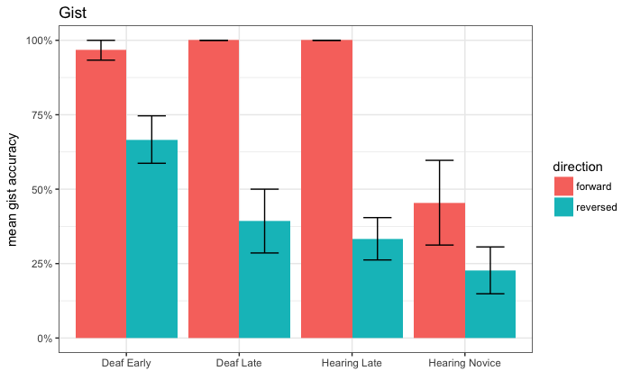

```r
# Gist bar chart
gist_bar <- fulldata %>% select(participant, maingroup, direction, gist) %>%
  group_by(maingroup, participant, direction) %>%
  summarise(gist = mean(gist)) %>%
  group_by(maingroup, direction) %>%
  summarise(mean = mean(gist),
            sd = sd(gist),
            count = n(),
            se = sd/sqrt(count)) %>%
  ungroup() %>%
  mutate(maingroup = case_when(
    maingroup == "DeafEarly" ~ "Deaf Early",
    maingroup == "DeafLate" ~ "Deaf Late",
    maingroup == "HearingLate" ~ "Hearing Late",
    maingroup == "HearingNovice" ~ "Hearing Novice"
    ))
ggplot(gist_bar, aes(x = maingroup, y = mean, fill = direction)) +
  geom_bar(stat = "identity", position = position_dodge()) +
  geom_errorbar(aes(ymin = mean-se, ymax = mean+se), position = position_dodge(0.9), width = 0.5) +
  labs(title = "Gist", x = "", y = "mean gist accuracy") +
  scale_y_continuous(labels = percent, limits = c(0,1)) + theme_bw()
```

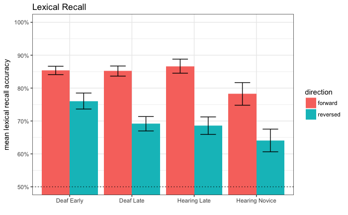

```r
# Lex bar chart
lex_bar <- fulldata %>% select(participant, maingroup, direction, acc) %>%
  group_by(maingroup, participant, direction) %>%
  summarise(acc = mean(acc, na.rm = TRUE)) %>%
  group_by(maingroup, direction) %>%
  summarise(mean = mean(acc, na.rm = TRUE),
            sd = sd(acc, na.rm = TRUE),
            count = n(),
            se = sd/sqrt(count)) %>%
  ungroup() %>%
  mutate(maingroup = case_when(
    maingroup == "DeafEarly" ~ "Deaf Early",
    maingroup == "DeafLate" ~ "Deaf Late",
    maingroup == "HearingLate" ~ "Hearing Late",
    maingroup == "HearingNovice" ~ "Hearing Novice"
    ))
ggplot(lex_bar, aes(x = maingroup, y = mean, fill = direction)) +
  geom_bar(stat = "identity", position = position_dodge()) +
  geom_errorbar(aes(ymin = mean-se, ymax = mean+se), position = position_dodge(0.9), width = 0.5) +
  labs(title = "Lexical Recall", x = "", y = "mean lexical recall accuracy") +
  scale_y_continuous(labels = percent, limits = c(0,1)) +
  geom_hline(yintercept = .5, linetype = "dotted") +
  coord_cartesian(ylim = c(.5,1)) + theme_bw()
```

And let’s calculate the average reduction in score due to reversal first is lex recall, then gist.

```r
reversal_lex <- fulldata %>%
  group_by(id, direction) %>%
  summarise(lex_mean = mean(acc, na.rm = TRUE)) %>%
  spread(direction, lex_mean) %>%
  group_by(id) %>%
  mutate(reversal = forward - reversed) %>%
  ungroup()
paste("lex mean", mean(reversal_lex$reversal))
```

```
[1] "lex mean 0.141570192307692"
```

```r
paste("lex sd", sd(reversal_lex$reversal))
```

```
[1] "lex sd 0.102655144785552"
```

```r
reversal_gist <- fulldata %>%
  group_by(id, direction) %>%
  summarise(gist_mean = mean(gist, na.rm = TRUE)) %>%
  spread(direction, gist_mean) %>%
  group_by(id) %>%
  mutate(reversal = forward - reversed) %>%
  ungroup()
paste("gist mean", mean(reversal_gist$reversal))
```

```
[1] "gist mean 0.451923076923077"
```

```r
paste("gist sd", sd(reversal_gist$reversal))
```

```
[1] "gist sd 0.39925930667527"
```

## ANOVA Plan

Next, we’re going to do ANOVAs. We’ll always do it in this order.

1. ANOVA with factors MainGroup & Direction
2. ANOVA with factor MainGroup, for Forward only
3. ANOVA with factor MainGroup, for Reverse only

(I also ran ANCOVAs before but now have taken them out…they are below: (4) ANCOVA with factor Direction, and covariate AoASL and Age, (5) Regression with variables AoASL and Age, for Forward only, (6) Regression with variables AoASL and Age, for Reverse only.)

I did not include Age as a covariate in the first 3 ANOVAs because they did not add to or change the model in any significant way.

## Gist ANOVAs

1. ANOVA with factors MainGroup & Direction.

```r
# First let's make the participant-level dataset with which we'll do our ANCOVAs.
participant_data <- fulldata %>%
  group_by(maingroup, participant, direction) %>%
  mutate(gist = mean(gist, na.rm = TRUE),
         acc = mean(acc, na.rm = TRUE)) %>%
  ungroup() %>%
  select(id, participant, hearing, maingroup, direction, age, aoasl, acc, gist) %>%
  distinct() %>%
  mutate(id = factor(id),
         participant = factor(participant),
         hearing = factor(hearing),
         maingroup = factor(maingroup),
         direction = factor(direction))
# # Gist ANOVA 1
# gist_aov1 <- aov(gist ~ maingroup * direction, data = participant_data)
# summary(gist_aov1)
# gist_lsd1 <- LSD.test(gist_aov1, "maingroup", group = FALSE)
# gist_lsd1$comparison
# Gist EZ ANOVA
ezANOVA(
  data = participant_data,
  dv = gist,
  wid = id,
  within = direction,
  between = maingroup,
  type = 3
)["ANOVA"]
```

```
Data is unbalanced (unequal N per group). Make sure you specified a well-considered value for the type argument to ezANOVA().
```

|  | Effect | DFn | DFd | F | p | p<.05 | ges |
| --- | --- | --- | --- | --- | --- | --- | --- |
| 2 | maingroup | 3 | 48 | 11.822628 | 6.427710e-06 | * | 0.2933497 |
| 3 | direction | 1 | 48 | 78.658826 | 1.106334e-11 | * | 0.4179543 |
| 4 | maingroup:direction | 3 | 48 | 4.524082 | 7.136090e-03 | * | 0.1102422 |

```
NA
```

2. ANOVA with factor MainGroup, for Forward only. *In the code is a Kruskal-Wallis test. And Chi-Sq too.*

```r
# # Gist ANOVA 2
# gist_aov2 <- aov(gist ~ maingroup, data = filter(participant_data, direction == "forward"))
# summary(gist_aov2)
# gist_lsd2 <- LSD.test(gist_aov2, "maingroup", group = FALSE)
# gist_lsd2$comparison
ezANOVA(
  data = filter(participant_data, direction == "forward"),
  dv = gist,
  wid = id,
  between = maingroup,
  type = 3
)["ANOVA"]
```

```
Data is unbalanced (unequal N per group). Make sure you specified a well-considered value for the type argument to ezANOVA().Coefficient covariances computed by hccm()
```

|  | Effect | DFn | DFd | F | p | p<.05 | ges |
| --- | --- | --- | --- | --- | --- | --- | --- |
| 2 | maingroup | 3 | 48 | 16.10591 | 2.231948e-07 | * | 0.5016494 |

```r
# # KW Non-parametric test (like one-way ANOVA)
# kruskal.test(gist ~ maingroup, data = as.matrix(filter(participant_data, direction == "forward")))
#
# # Chi Sq
# gist_chisq_fw <- participant_data %>%
#   ungroup() %>%
#   filter(direction == "forward") %>%
#   select(maingroup, gist) %>%
#   group_by(maingroup, gist) %>%
#   summarise(count = n()) %>%
#   spread(gist, count) %>%
#   rename(none = "0",
#          one = "0.5",
#          both = "1")
#
# gist_chisq_fw[is.na(gist_chisq_fw)] <- 0L
# gist_chisq_fw <- cbind(gist_chisq_fw[,"none"], gist_chisq_fw[,"one"], gist_chisq_fw[,"both"])
# chisq.test(gist_chisq_fw)
```

3. ANOVA with factor MainGroup, for Reverse only. *In the code is a Kruskal-Wallis test. And Chi-Sq too.*

```r
# # Gist ANOVA 3
# gist_aov3 <- aov(gist ~ maingroup, data = filter(participant_data, direction == "reversed"))
# summary(gist_aov3)
# gist_lsd3 <- LSD.test(gist_aov3, "maingroup", group = FALSE)
# gist_lsd3$comparison
ezANOVA(
  data = filter(participant_data, direction == "reversed"),
  dv = gist,
  wid = id,
  between = maingroup,
  type = 3
)["ANOVA"]
```

```
Data is unbalanced (unequal N per group). Make sure you specified a well-considered value for the type argument to ezANOVA().Coefficient covariances computed by hccm()
```

|  | Effect | DFn | DFd | F | p | p<.05 | ges |
| --- | --- | --- | --- | --- | --- | --- | --- |
| 2 | maingroup | 3 | 48 | 4.766038 | 0.005479751 | * | 0.2295112 |

```r
# # KW Non-parametric test (like one-way ANOVA)
# kruskal.test(gist ~ maingroup, data = as.matrix(filter(participant_data, direction == "reversed")))
#
# # Chi Sq
# gist_chisq_rv <- participant_data %>%
#   ungroup() %>%
#   filter(direction == "reversed") %>%
#   select(maingroup, gist) %>%
#   group_by(maingroup, gist) %>%
#   summarise(count = n()) %>%
#   spread(gist, count) %>%
#   rename(none = "0",
#          one = "0.5",
#          both = "1")
#
# gist_chisq_rv[is.na(gist_chisq_rv)] <- 0L
# gist_chisq_rv <- cbind(gist_chisq_rv[,"none"], gist_chisq_rv[,"one"], gist_chisq_rv[,"both"])
# chisq.test(gist_chisq_rv)
```

## Lexical Recall ANOVAs

1. ANOVA with factors MainGroup & Direction.

```r
# # Lexical Recall ANOVA 1
# acc_aov1 <- aov(acc ~ maingroup * direction, data = participant_data)
# summary(acc_aov1)
# acc_lsd1 <- LSD.test(acc_aov1, "maingroup", group = FALSE)
# acc_lsd1$comparison
ezANOVA(
  data = participant_data,
  dv = acc,
  wid = id,
  within = direction,
  between = maingroup,
  type = 3
)["ANOVA"]
```

```
Data is unbalanced (unequal N per group). Make sure you specified a well-considered value for the type argument to ezANOVA().
```

|  | Effect | DFn | DFd | F | p | p<.05 | ges |
| --- | --- | --- | --- | --- | --- | --- | --- |
| 2 | maingroup | 3 | 48 | 4.054380 | 1.199347e-02 | * | 0.1431973 |
| 3 | direction | 1 | 48 | 106.249790 | 9.301712e-14 | * | 0.4297422 |
| 4 | maingroup:direction | 3 | 48 | 1.961875 | 1.322862e-01 |  | 0.0400719 |

```
NA
```

2. ANOVA with factor MainGroup, for Forward only.

```r
# # Lexical Recall ANOVA 2
# acc_aov2 <- aov(acc ~ maingroup, data = filter(participant_data, direction == "forward"))
# summary(acc_aov2)
# acc_lsd2 <- LSD.test(acc_aov2, "maingroup", group = FALSE)
# acc_lsd2$comparison
ezANOVA(
  data = filter(participant_data, direction == "forward"),
  dv = acc,
  wid = id,
  between = maingroup,
  type = 3
)["ANOVA"]
```

```
Data is unbalanced (unequal N per group). Make sure you specified a well-considered value for the type argument to ezANOVA().Coefficient covariances computed by hccm()
```

|  | Effect | DFn | DFd | F | p | p<.05 | ges |
| --- | --- | --- | --- | --- | --- | --- | --- |
| 2 | maingroup | 3 | 48 | 2.983502 | 0.04037159 | * | 0.1571629 |

```
NA
```

3. ANOVA with factor MainGroup, for Reverse only.

```r
# # Lexical Recall ANOVA 3
# acc_aov3 <- aov(acc ~ maingroup, data = filter(participant_data, direction == "reversed"))
# summary(acc_aov3)
# acc_lsd3 <- LSD.test(acc_aov3, "maingroup", group = FALSE)
# acc_lsd3$comparison
ezANOVA(
  data = filter(participant_data, direction == "reversed"),
  dv = acc,
  wid = id,
  between = maingroup,
  type = 3
)["ANOVA"]
```

```
Data is unbalanced (unequal N per group). Make sure you specified a well-considered value for the type argument to ezANOVA().Coefficient covariances computed by hccm()
```

|  | Effect | DFn | DFd | F | p | p<.05 | ges |
| --- | --- | --- | --- | --- | --- | --- | --- |
| 2 | maingroup | 3 | 48 | 3.562122 | 0.0208508 | * | 0.1820928 |

```
NA
```

# AoA Correlations

Next, we want to look at correlations between AoA and Gist, and betwen AoA and Lexical Recall. Rain asked for forward and reversed separately (1) deaf only, (2) hearing only, and (3) both. Let’s make it work.

```r
# Let's make participant-level data, and have forward/reversed in separate columns
lexgist_data <- fulldata %>%
  group_by(maingroup, participant, direction) %>%
  mutate(gist = mean(gist, na.rm = TRUE),
         lex = mean(acc, na.rm = TRUE)) %>%
  ungroup() %>%
  select(maingroup, participant, hearing, direction, aoasl, signyrs, age, gist, lex) %>%
  distinct() %>%
  gather(metric, value, gist:lex) %>%
  unite(metricvalue, c(metric, direction), sep = "_") %>%
  spread(metricvalue, value) %>%
  select(-participant, -maingroup)
lexgist_deaf <- lexgist_data %>% filter(hearing == "Deaf") %>% select(-hearing)
lexgist_hearing <- lexgist_data %>% filter(hearing == "Hearing") %>% select(-hearing)
lexgist_all <- lexgist_data %>% select(-hearing)
# Load awesome function to make correlation tables with stars for significance
# From: https://myowelt.blogspot.co.uk/2008/04/beautiful-correlation-tables-in-r.html
corstarsl <- function(x){
require(Hmisc)
x <- as.matrix(x)
R <- Hmisc::rcorr(x)$r
p <- Hmisc::rcorr(x)$P
## define notions for significance levels; spacing is important.
mystars <- ifelse(p < .001, "***", ifelse(p < .01, "** ", ifelse(p < .05, "* ", " ")))
## trunctuate the matrix that holds the correlations to two decimal
R <- format(round(cbind(rep(-1.11, ncol(x)), R), 2))[,-1]
## build a new matrix that includes the correlations with their apropriate stars
Rnew <- matrix(paste(R, mystars, sep=""), ncol=ncol(x))
diag(Rnew) <- paste(diag(R), " ", sep="")
rownames(Rnew) <- colnames(x)
colnames(Rnew) <- paste(colnames(x), "", sep="")
## remove upper triangle
Rnew <- as.matrix(Rnew)
Rnew[upper.tri(Rnew, diag = TRUE)] <- ""
Rnew <- as.data.frame(Rnew)
## remove last column and return the matrix (which is now a data frame)
Rnew <- cbind(Rnew[1:length(Rnew)-1])
return(Rnew)
}
# Correlations for Deaf
print("DEAF Correlations - Pearson's r")
```

```
[1] "DEAF Correlations - Pearson's r"
```

```r
#corstarsl(lexgist_deaf)
Hmisc::rcorr(as.matrix(lexgist_deaf))$r
```

```
                    aoasl     signyrs        age gist_forward gist_reversed lex_forward
aoasl          1.00000000 -0.50188271  0.2569266   0.08266372   -0.25585944  0.14743344
signyrs       -0.50188271  1.00000000  0.7005996   0.18321126   -0.01264108  0.27968506
age            0.25692658  0.70059957  1.0000000   0.27454460   -0.17264941  0.42997836
gist_forward   0.08266372  0.18321126  0.2745446   1.00000000    0.01762268 -0.08155558
gist_reversed -0.25585944 -0.01264108 -0.1726494   0.01762268    1.00000000  0.02667228
lex_forward    0.14743344  0.27968506  0.4299784  -0.08155558    0.02667228  1.00000000
lex_reversed  -0.25601869  0.06666991 -0.1276564  -0.09770669    0.36021802  0.35984896
              lex_reversed
aoasl          -0.25601869
signyrs         0.06666991
age            -0.12765639
gist_forward   -0.09770669
gist_reversed   0.36021802
lex_forward     0.35984896
lex_reversed    1.00000000
```

```r
print("DEAF Correlations - P-values")
```

```
[1] "DEAF Correlations - P-values"
```

```r
Hmisc::rcorr(as.matrix(lexgist_deaf))$P
```

```
                    aoasl      signyrs          age gist_forward gist_reversed lex_forward
aoasl                  NA 5.536859e-03 1.784812e-01    0.6698839    0.18035489  0.44533535
signyrs       0.005536859           NA 2.316794e-05    0.3414473    0.94810844  0.14172234
age           0.178481235 2.316794e-05           NA    0.1495001    0.37046624  0.01990878
gist_forward  0.669883870 3.414473e-01 1.495001e-01           NA    0.92770439  0.67406670
gist_reversed 0.180354887 9.481084e-01 3.704662e-01    0.9277044            NA  0.89076150
lex_forward   0.445335355 1.417223e-01 1.990878e-02    0.6740667    0.89076150          NA
lex_reversed  0.180074401 7.311333e-01 5.093053e-01    0.6140989    0.05492031  0.05518763
              lex_reversed
aoasl           0.18007440
signyrs         0.73113326
age             0.50930528
gist_forward    0.61409886
gist_reversed   0.05492031
lex_forward     0.05518763
lex_reversed            NA
```

```r
cat(paste("","\n",""))
```

```r
# Correlations for Hearing
print("HEARING Correlations - Pearson's r")
```

```
[1] "HEARING Correlations - Pearson's r"
```

```r
#corstarsl(lexgist_hearing)
Hmisc::rcorr(as.matrix(lexgist_hearing))$r
```

```
                    aoasl     signyrs       age gist_forward gist_reversed lex_forward
aoasl          1.00000000 -0.07887014 0.3468185  -0.15525565    0.07815752   0.0250027
signyrs       -0.07887014  1.00000000 0.9021947   0.57814668    0.28845747   0.3672566
age            0.34681845  0.90219467 1.0000000   0.44651471    0.30963454   0.3093175
gist_forward  -0.15525565  0.57814668 0.4465147   1.00000000    0.29502173   0.5715457
gist_reversed  0.07815752  0.28845747 0.3096345   0.29502173    1.00000000   0.3568237
lex_forward    0.02500270  0.36725659 0.3093175   0.57154568    0.35682373   1.0000000
lex_reversed   0.01411304  0.20828810 0.2013959   0.07645805    0.57951177   0.3655834
              lex_reversed
aoasl           0.01411304
signyrs         0.20828810
age             0.20139593
gist_forward    0.07645805
gist_reversed   0.57951177
lex_forward     0.36558335
lex_reversed    1.00000000
```

```r
print("HEARING Correlations - P-values")
```

```
[1] "HEARING Correlations - P-values"
```

```r
Hmisc::rcorr(as.matrix(lexgist_hearing))$P
```

```
                  aoasl      signyrs          age gist_forward gist_reversed lex_forward
aoasl                NA 7.205586e-01 1.049514e-01  0.479339901   0.722986491 0.909840966
signyrs       0.7205586           NA 4.046902e-09  0.003857506   0.181932485 0.084723421
age           0.1049514 4.046902e-09           NA  0.032691678   0.150502497 0.150942614
gist_forward  0.4793399 3.857506e-03 3.269168e-02           NA   0.171744872 0.004385473
gist_reversed 0.7229865 1.819325e-01 1.505025e-01  0.171744872            NA 0.094647564
lex_forward   0.9098410 8.472342e-02 1.509426e-01  0.004385473   0.094647564          NA
lex_reversed  0.9490401 3.402228e-01 3.567949e-01  0.728786944   0.003755274 0.086260173
              lex_reversed
aoasl          0.949040146
signyrs        0.340222821
age            0.356794883
gist_forward   0.728786944
gist_reversed  0.003755274
lex_forward    0.086260173
lex_reversed            NA
```

```r
cat(paste("","\n",""))
```

```r
# Correlations for All
print("ALL Correlations - Pearson's r")
```

```
[1] "ALL Correlations - Pearson's r"
```

```r
#corstarsl(lexgist_all)
Hmisc::rcorr(as.matrix(lexgist_all))$r
```

```
                    aoasl    signyrs        age gist_forward gist_reversed lex_forward
aoasl          1.00000000 -0.7852245 -0.3136458   -0.3230903    -0.3922803 -0.08115845
signyrs       -0.78522450  1.0000000  0.8314757    0.4956183     0.3356193  0.29698990
age           -0.31364575  0.8314757  1.0000000    0.4602616     0.1930257  0.36318285
gist_forward  -0.32309031  0.4956183  0.4602616    1.0000000     0.2712760  0.49279109
gist_reversed -0.39228034  0.3356193  0.1930257    0.2712760     1.0000000  0.21701817
lex_forward   -0.08115845  0.2969899  0.3631829    0.4927911     0.2170182  1.00000000
lex_reversed  -0.33945210  0.3182316  0.1886432    0.1521110     0.4921550  0.38007714
              lex_reversed
aoasl           -0.3394521
signyrs          0.3182316
age              0.1886432
gist_forward     0.1521110
gist_reversed    0.4921550
lex_forward      0.3800771
lex_reversed     1.0000000
```

```r
print("ALL Correlations - P-values")
```

```
[1] "ALL Correlations - P-values"
```

```r
Hmisc::rcorr(as.matrix(lexgist_all))$P
```

```
                     aoasl      signyrs          age gist_forward gist_reversed  lex_forward
aoasl                   NA 5.523138e-12 2.356068e-02 0.0194786591  0.0040239674 0.5673489974
signyrs       5.523138e-12           NA 2.309264e-14 0.0001870210  0.0150006763 0.0325116095
age           2.356068e-02 2.309264e-14           NA 0.0005965582  0.1703671283 0.0081373865
gist_forward  1.947866e-02 1.870210e-04 5.965582e-04           NA  0.0517394727 0.0002061625
gist_reversed 4.023967e-03 1.500068e-02 1.703671e-01 0.0517394727            NA 0.1222543184
lex_forward   5.673490e-01 3.251161e-02 8.137387e-03 0.0002061625  0.1222543184           NA
lex_reversed  1.382017e-02 2.149677e-02 1.804672e-01 0.2817023589  0.0002107074 0.0054478292
              lex_reversed
aoasl         0.0138201739
signyrs       0.0214967652
age           0.1804672425
gist_forward  0.2817023589
gist_reversed 0.0002107074
lex_forward   0.0054478292
lex_reversed            NA
```

I’m also including nicely formatted tables with *** indicators of significance for quick referencing. Order: Deaf, Hearing, All.

```r
corstarsl(lexgist_deaf)
```

|  | aoasl | signyrs | age | gist_forward | gist_reversed | lex_forward |
| --- | --- | --- | --- | --- | --- | --- |
| aoasl |  |  |  |  |  |  |
| signyrs | -0.50** |  |  |  |  |  |
| age | 0.26 | 0.70*** |  |  |  |  |
| gist_forward | 0.08 | 0.18 | 0.27 |  |  |  |
| gist_reversed | -0.26 | -0.01 | -0.17 | 0.02 |  |  |
| lex_forward | 0.15 | 0.28 | 0.43* | -0.08 | 0.03 |  |
| lex_reversed | -0.26 | 0.07 | -0.13 | -0.10 | 0.36 | 0.36 |

```r
corstarsl(lexgist_hearing)
```

|  | aoasl | signyrs | age | gist_forward | gist_reversed | lex_forward |
| --- | --- | --- | --- | --- | --- | --- |
| aoasl |  |  |  |  |  |  |
| signyrs | -0.08 |  |  |  |  |  |
| age | 0.35 | 0.90*** |  |  |  |  |
| gist_forward | -0.16 | 0.58** | 0.45* |  |  |  |
| gist_reversed | 0.08 | 0.29 | 0.31 | 0.30 |  |  |
| lex_forward | 0.03 | 0.37 | 0.31 | 0.57** | 0.36 |  |
| lex_reversed | 0.01 | 0.21 | 0.20 | 0.08 | 0.58** | 0.37 |

```r
corstarsl(lexgist_all)
```

|  | aoasl | signyrs | age | gist_forward | gist_reversed | lex_forward |
| --- | --- | --- | --- | --- | --- | --- |
| aoasl |  |  |  |  |  |  |
| signyrs | -0.79*** |  |  |  |  |  |
| age | -0.31* | 0.83*** |  |  |  |  |
| gist_forward | -0.32* | 0.50*** | 0.46*** |  |  |  |
| gist_reversed | -0.39** | 0.34* | 0.19 | 0.27 |  |  |
| lex_forward | -0.08 | 0.30* | 0.36** | 0.49*** | 0.22 |  |
| lex_reversed | -0.34* | 0.32* | 0.19 | 0.15 | 0.49*** | 0.38** |

## Scatterplot of Correlations

Let’s visualize what’s happening with the correlations here.

[output not shown]

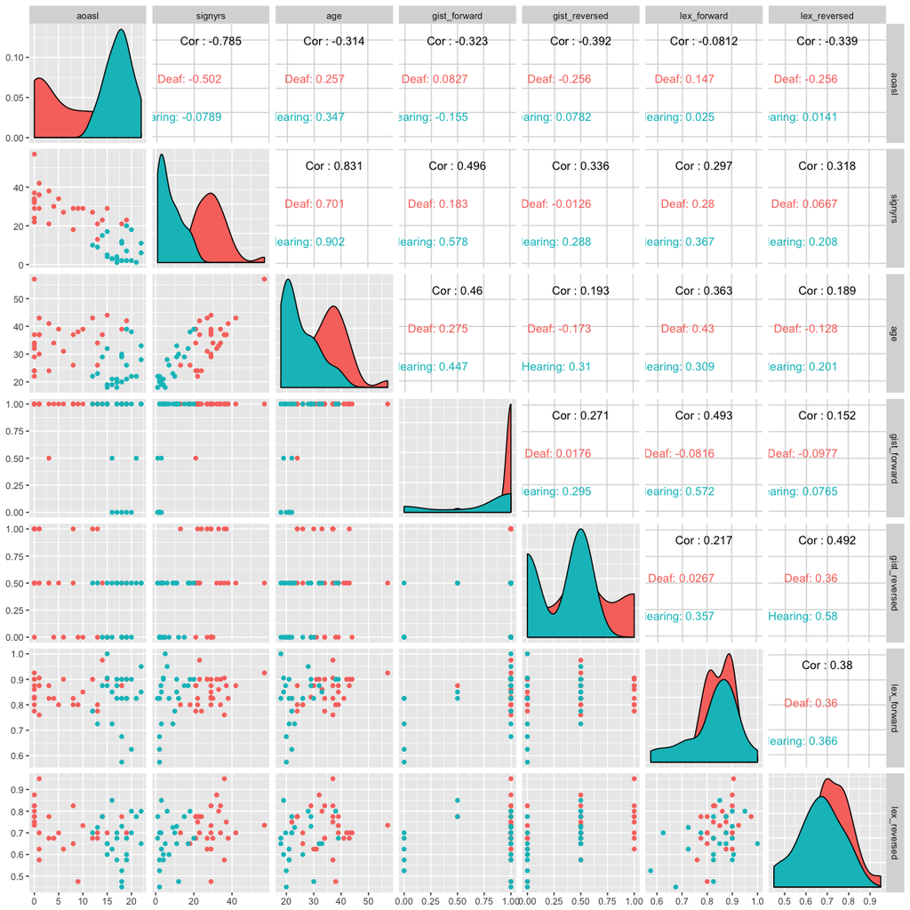

```r
ggpairs(lexgist_data, columns = c(2:8), aes(color = hearing))
```

# Eye Gaze Data

Now eye gaze data. Boxplots first. Also here, we’re renaming “chin” to “neck” because that’s what it actually is! But we also have to fix all NA’s in the percentages to zeros, becuase that’s what they actually are.

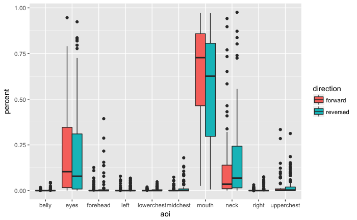

```r
# rename chin to neck
fulldata <- fulldata %>%
  rename(neck = chin) %>%
  gather(aoi, percent, belly:upperchest)
# Fix all NA's in Percent column to 0
fixpercent <- fulldata$percent
fulldata$percent <- coalesce(fixpercent, 0)
fulldata <- fulldata %>%
  spread(aoi, percent)
fulldata %>%
  filter(eye_exclude == FALSE) %>%
  select(direction, belly:upperchest) %>%
  gather(aoi, percent, belly:upperchest) %>%
  ggplot(aes(x = aoi, y = percent, fill = direction)) + geom_boxplot()
```

But let’s try error charts too! Instead of boxplots.

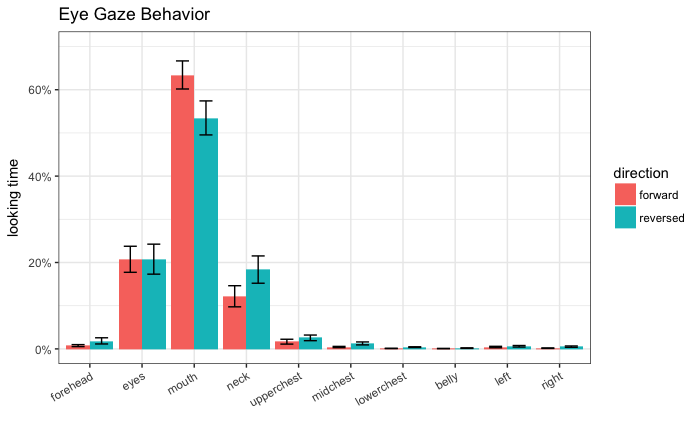

```r
fulldata_error <- fulldata %>%
  filter(eye_exclude == FALSE) %>%
  gather(aoi, percent, belly:upperchest) %>%
  group_by(id, direction, aoi) %>%
  summarise(percent = mean(percent, na.rm = TRUE)) %>%
  ungroup() %>%
  distinct() %>%
  group_by(direction, aoi) %>%
  summarise(mean = mean(percent, na.rm = TRUE),
            sd = sd(percent, na.rm = TRUE),
            count = n(),
            se = sd/sqrt(count))
fulldata_error$aoi <- fct_relevel(fulldata_error$aoi, c("forehead","eyes","mouth","neck","upperchest",
                                                        "midchest","lowerchest","belly","left","right"))
fulldata_error %>%
  ggplot(aes(x = aoi, y = mean, fill = direction)) +
  geom_bar(stat = "identity", position = position_dodge()) +
  geom_errorbar(aes(ymin = mean-se, ymax = mean+se), position = position_dodge(0.9), width = 0.5) +
  labs(title = "Eye Gaze Behavior", x = "", y = "looking time") +
  scale_y_continuous(labels = percent, limits = c(0,.70)) +
  theme_bw() +
  theme(axis.text.x = element_text(angle = 30, hjust = 1, vjust = 1))
```

And a table of eye gaze results too

```r
fulldata_gazetable <- fulldata %>%
  filter(eye_exclude == FALSE) %>%
  gather(aoi, percent, belly:upperchest) %>%
  group_by(id, maingroup, direction, aoi) %>%
  summarise(percent = mean(percent, na.rm = TRUE)) %>%
  ungroup() %>%
  distinct() %>%
  group_by(maingroup, direction, aoi) %>%
  summarise(mean = mean(percent, na.rm = TRUE),
            sd = sd(percent, na.rm = TRUE)) %>%
  mutate(mean = round(mean*100,1),
         sd = round(sd*100,1)) %>%
  mutate(value = paste(mean, sd, sep = " ± ")) %>%
  mutate(value = paste(value, "%", sep = ""))
fulldata_gazetable$aoi <- fct_relevel(fulldata_gazetable$aoi, c("forehead","eyes","mouth","neck","upperchest",
                                                        "midchest","lowerchest","belly","left","right"))
fulldata_gazetable %>%
  ungroup() %>%
  select(-mean, -sd) %>%
  spread(aoi, value)
```

| maingroup | direction | forehead | eyes | mouth | neck | upperchest | midchest | lowerchest | belly | left | right |
| --- | --- | --- | --- | --- | --- | --- | --- | --- | --- | --- | --- |
| DeafEarly | forward | 0.2 ± 0.6% | 15.8 ± 14.9% | 65.3 ± 24.1% | 17.2 ± 24.2% | 1.4 ± 3.7% | 0.1 ± 0.2% | 0 ± 0% | 0 ± 0% | 0 ± 0% | 0 ± 0% |
| DeafEarly | reversed | 1.9 ± 5.3% | 14.7 ± 14.2% | 57.6 ± 27.4% | 24 ± 30.4% | 0.8 ± 1% | 0.2 ± 0.3% | 0.2 ± 0.4% | 0.2 ± 0.5% | 0.1 ± 0.4% | 0.3 ± 0.6% |
| DeafLate | forward | 0.8 ± 1.9% | 18.8 ± 17.4% | 70.4 ± 19% | 8.9 ± 15.2% | 0.4 ± 0.9% | 0.2 ± 0.3% | 0.1 ± 0.3% | 0.1 ± 0.2% | 0.2 ± 0.8% | 0.1 ± 0.1% |
| DeafLate | reversed | 1 ± 2.6% | 20.5 ± 27.2% | 64.4 ± 27.2% | 10.3 ± 15.5% | 1.6 ± 2.8% | 0.9 ± 1.8% | 0.2 ± 0.3% | 0 ± 0.1% | 0.8 ± 1.8% | 0.3 ± 0.9% |
| HearingLate | forward | 1.6 ± 2.4% | 29 ± 28.3% | 56 ± 27.1% | 10.8 ± 16% | 1.2 ± 2% | 0.3 ± 0.8% | 0.1 ± 0.1% | 0.1 ± 0.1% | 0.8 ± 1.5% | 0.2 ± 0.4% |
| HearingLate | reversed | 4.4 ± 8% | 31.5 ± 33.6% | 43.2 ± 33.3% | 15.2 ± 19.7% | 2.1 ± 3.6% | 1 ± 1.7% | 0.6 ± 0.6% | 0.3 ± 0.7% | 0.7 ± 1.4% | 1 ± 1.6% |
| HearingNovice | forward | 0.6 ± 1% | 21 ± 26.5% | 60.1 ± 23.7% | 11.1 ± 11.2% | 4.1 ± 7.1% | 1.3 ± 1.9% | 0.3 ± 0.3% | 0.2 ± 0.3% | 0.9 ± 1.8% | 0.4 ± 0.7% |
| HearingNovice | reversed | 0.1 ± 0.2% | 17.7 ± 21.4% | 46.1 ± 20.6% | 23.6 ± 19.1% | 6.5 ± 7.8% | 3.5 ± 3.8% | 0.8 ± 0.9% | 0.2 ± 0.4% | 0.9 ± 1.1% | 0.6 ± 1.2% |

```r
fulldata_total <- fulldata %>%
  filter(eye_exclude == FALSE) %>%
  gather(aoi, percent, belly:upperchest) %>%
  group_by(aoi) %>%
  summarise(percent = mean(percent, na.rm = TRUE)) %>%
  spread(aoi, percent)
#sum(fulldata_total$eyes, fulldata_total$mouth, fulldata_total$neck)
#fulldata_total$left
#fulldata_total$right
```

## Big Three-Way ANOVA

Now we’re going to try a three-way Group x Direction x AOI ANOVA with the top 3 AOIs (Eyes, Mouth, Neck)

```
$ANOVA
                   Effect DFn DFd          F            p p<.05          ges
2               maingroup   3  47  3.0877532 3.602912e-02     * 0.0019613548
3               direction   1  47 14.6917045 3.751848e-04     * 0.0008045246
5                     aoi   2  94 38.9261560 4.838451e-13     * 0.4115853001
4     maingroup:direction   3  47  0.8509636 4.731139e-01       0.0001398905
6           maingroup:aoi   6  94  1.1224334 3.553342e-01       0.0570561521
7           direction:aoi   2  94  7.0028846 1.462185e-03     * 0.0208462714
8 maingroup:direction:aoi   6  94  0.6318533 7.044042e-01       0.0057298396
```

## Left Vs Right

```
$ANOVA
         Effect DFn DFd         F          p p<.05        ges
2     maingroup   3  47 2.5418616 0.06755936       0.09343220
3           aoi   1  47 1.8880127 0.17594392       0.01444195
4 maingroup:aoi   3  47 0.8434728 0.47700559       0.01926124
```

## Interactions Visualization

First are the maingroup:aoi charts *The error bars are not 100% accurate, I took a quick-n-easy way around*

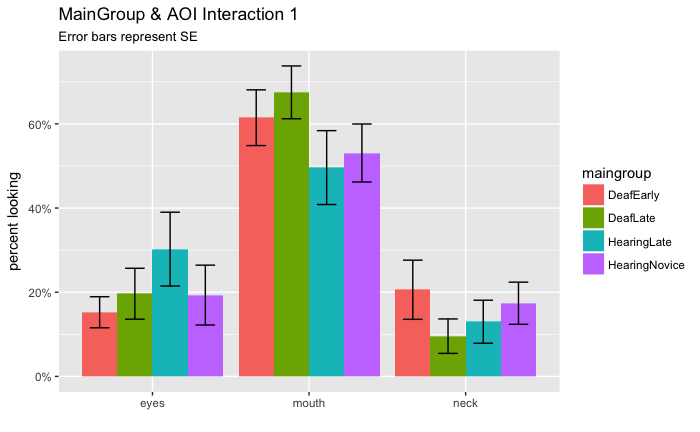

```r
aoi3_interactions_maingroupaoi <- fulldata %>%
  filter(eye_exclude == FALSE) %>%
  select(id, participant, maingroup, direction, eyes, mouth, neck) %>%
  gather(aoi, percent, c(eyes, mouth, neck)) %>%
  group_by(id, maingroup, direction, aoi) %>%
  mutate(percent = mean(percent, na.rm = TRUE)) %>%
  distinct() %>%
  group_by(maingroup, aoi) %>%
  summarise(mean = mean(percent, na.rm = TRUE),
            sd = sd(percent, na.rm = TRUE),
            count = n()/2,
            se = sd/sqrt(count))
# I need to first collapse across stories for each participant...here I didn't. Must fix later.
aoi3_interactions_maingroupaoi %>%
  ggplot(aes(x = aoi, y = mean, fill = maingroup)) +
  geom_bar(stat = "identity", position = position_dodge()) +
  geom_errorbar(aes(ymin = mean-se, ymax = mean+se), position = position_dodge(0.9), width = 0.5) +
  labs(title = "MainGroup & AOI Interaction 1", subtitle = "Error bars represent SE", x = "", y = "percent looking") +
  scale_y_continuous(labels = percent)
```

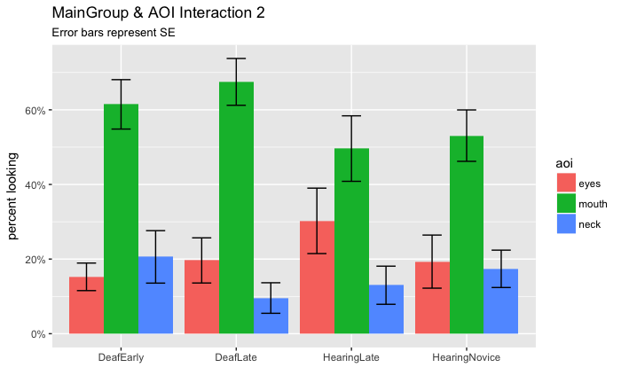

```r
aoi3_interactions_maingroupaoi %>%
  ggplot(aes(x = maingroup, y = mean, fill = aoi)) +
  geom_bar(stat = "identity", position = position_dodge()) +
  geom_errorbar(aes(ymin = mean-se, ymax = mean+se), position = position_dodge(0.9), width = 0.5) +
  labs(title = "MainGroup & AOI Interaction 2", subtitle = "Error bars represent SE", x = "", y = "percent looking") +
  scale_y_continuous(labels = percent)
```

First are the direction:aoi charts *The error bars are not 100% accurate, I took a quick-n-easy way around*

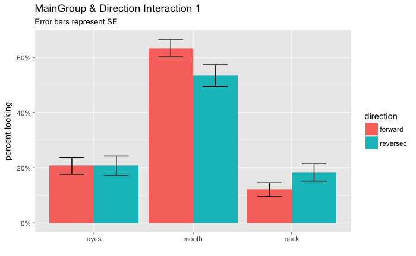

```r
aoi3_interactions_directionaoi <- fulldata %>%
  filter(eye_exclude == FALSE) %>%
  select(id, participant, maingroup, direction, eyes, mouth, neck) %>%
  gather(aoi, percent, c(eyes, mouth, neck)) %>%
  group_by(id, maingroup, direction, aoi) %>%
  mutate(percent = mean(percent, na.rm = TRUE)) %>%
  distinct() %>%
  group_by(direction, aoi) %>%
  summarise(mean = mean(percent, na.rm = TRUE),
            sd = sd(percent, na.rm = TRUE),
            count = n(),
            se = sd/sqrt(count))
# I need to first collapse across stories for each participant...here I didn't. Must fix later.
aoi3_interactions_directionaoi %>%
  ggplot(aes(x = aoi, y = mean, fill = direction)) +
  geom_bar(stat = "identity", position = position_dodge()) +
  geom_errorbar(aes(ymin = mean-se, ymax = mean+se), position = position_dodge(0.9), width = 0.5) +
  labs(title = "MainGroup & Direction Interaction 1", subtitle = "Error bars represent SE", x = "", y = "percent looking") +
  scale_y_continuous(labels = percent)
```

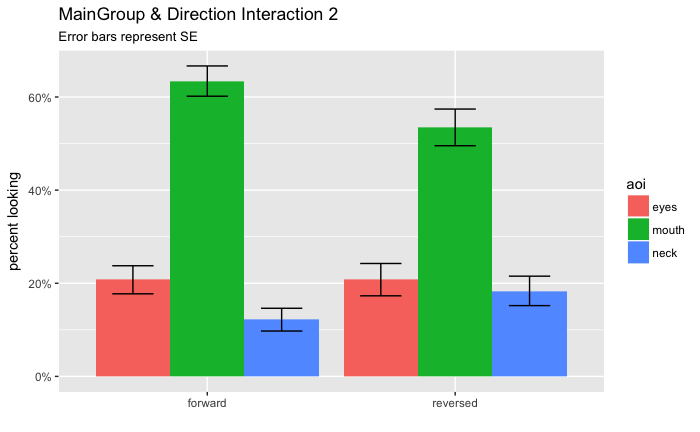

```r
aoi3_interactions_directionaoi %>%
  ggplot(aes(x = direction, y = mean, fill = aoi)) +
  geom_bar(stat = "identity", position = position_dodge()) +
  geom_errorbar(aes(ymin = mean-se, ymax = mean+se), position = position_dodge(0.9), width = 0.5) +
  labs(title = "MainGroup & Direction Interaction 2", subtitle = "Error bars represent SE", x = "", y = "percent looking") +
  scale_y_continuous(labels = percent)
```

## All the AOI means

Let’s get tables of our means here, in various configurations

| maingroup | direction | eyes | mouth | neck | total |
| --- | --- | --- | --- | --- | --- |
| DeafEarly | forward | 0.1578501 | 0.6529546 | 0.17151227 | 0.9823169 |
| DeafEarly | reversed | 0.1469463 | 0.5763811 | 0.24022699 | 0.9635544 |
| DeafLate | forward | 0.1882474 | 0.7035952 | 0.08906287 | 0.9809055 |
| DeafLate | reversed | 0.2051604 | 0.6440347 | 0.10264339 | 0.9518385 |
| HearingLate | forward | 0.2897510 | 0.5601317 | 0.10758852 | 0.9574711 |
| HearingLate | reversed | 0.3151304 | 0.4321741 | 0.15220314 | 0.8995076 |
| HearingNovice | forward | 0.2097915 | 0.6010221 | 0.11132841 | 0.9221420 |
| HearingNovice | reversed | 0.1765839 | 0.4606678 | 0.23639680 | 0.8736485 |

| maingroup | eyes | mouth | neck | total |
| --- | --- | --- | --- | --- |
| DeafEarly | 0.1523982 | 0.6146678 | 0.20586963 | 0.9729357 |
| DeafLate | 0.1967039 | 0.6738150 | 0.09585313 | 0.9663720 |
| HearingLate | 0.3024407 | 0.4961529 | 0.12989583 | 0.9284894 |
| HearingNovice | 0.1931877 | 0.5308450 | 0.17386260 | 0.8978952 |

| direction | eyes | mouth | neck | total |
| --- | --- | --- | --- | --- |
| forward | 0.2114100 | 0.6294259 | 0.1198730 | 0.9607089 |
| reversed | 0.2109553 | 0.5283144 | 0.1828676 | 0.9221372 |

| aoi | percent |
| --- | --- |
| eyes | 0.2111826 |
| mouth | 0.5788702 |
| neck | 0.1513703 |

## Eyes

1. ANOVA with factors MainGroup & Direction.

```
Converting "id" to factor for ANOVA.Converting "direction" to factor for ANOVA.Converting "maingroup" to factor for ANOVA.Data is unbalanced (unequal N per group). Make sure you specified a well-considered value for the type argument to ezANOVA().
```

|  | Effect | DFn | DFd | F | p | p<.05 | ges |
| --- | --- | --- | --- | --- | --- | --- | --- |
| 2 | maingroup | 3 | 47 | 1.130396700 | 0.3464255 |  | 5.737108e-02 |
| 3 | direction | 1 | 47 | 0.004506312 | 0.9467637 |  | 1.500243e-05 |
| 4 | maingroup:direction | 3 | 47 | 0.226665012 | 0.8773746 |  | 2.258762e-03 |

```
NA
```

2. ANOVA with factor MainGroup, for Forward only.

```
Converting "id" to factor for ANOVA.Converting "maingroup" to factor for ANOVA.Data is unbalanced (unequal N per group). Make sure you specified a well-considered value for the type argument to ezANOVA().Coefficient covariances computed by hccm()
```

|  | Effect | DFn | DFd | F | p | p<.05 | ges |
| --- | --- | --- | --- | --- | --- | --- | --- |
| 2 | maingroup | 3 | 47 | 0.8280331 | 0.485112 |  | 0.05019995 |

```
NA
```

3. ANOVA with factor MainGroup, for Reverse only.

```
Converting "id" to factor for ANOVA.Converting "maingroup" to factor for ANOVA.Data is unbalanced (unequal N per group). Make sure you specified a well-considered value for the type argument to ezANOVA().Coefficient covariances computed by hccm()
```

|  | Effect | DFn | DFd | F | p | p<.05 | ges |
| --- | --- | --- | --- | --- | --- | --- | --- |
| 2 | maingroup | 3 | 47 | 1.117022 | 0.3517093 |  | 0.06655402 |

```
NA
```

## Mouth

1. ANOVA with factors MainGroup & Direction.

```
Converting "id" to factor for ANOVA.Converting "direction" to factor for ANOVA.Converting "maingroup" to factor for ANOVA.Data is unbalanced (unequal N per group). Make sure you specified a well-considered value for the type argument to ezANOVA().
```

|  | Effect | DFn | DFd | F | p | p<.05 | ges |
| --- | --- | --- | --- | --- | --- | --- | --- |
| 2 | maingroup | 3 | 47 | 1.3738716 | 0.262310072 |  | 0.06857815 |
| 3 | direction | 1 | 47 | 11.4134174 | 0.001473422 | * | 0.03749216 |
| 4 | maingroup:direction | 3 | 47 | 0.5548409 | 0.647450064 |  | 0.00564872 |

```
NA
```

2. ANOVA with factor MainGroup, for Forward only.

```
Converting "id" to factor for ANOVA.Converting "maingroup" to factor for ANOVA.Data is unbalanced (unequal N per group). Make sure you specified a well-considered value for the type argument to ezANOVA().Coefficient covariances computed by hccm()
```

|  | Effect | DFn | DFd | F | p | p<.05 | ges |
| --- | --- | --- | --- | --- | --- | --- | --- |
| 2 | maingroup | 3 | 47 | 0.7428549 | 0.5319064 |  | 0.04526975 |

```
NA
```

3. ANOVA with factor MainGroup, for Reverse only.

```
Converting "id" to factor for ANOVA.Converting "maingroup" to factor for ANOVA.Data is unbalanced (unequal N per group). Make sure you specified a well-considered value for the type argument to ezANOVA().Coefficient covariances computed by hccm()
```

|  | Effect | DFn | DFd | F | p | p<.05 | ges |
| --- | --- | --- | --- | --- | --- | --- | --- |
| 2 | maingroup | 3 | 47 | 1.608183 | 0.2000782 |  | 0.09309391 |

```
NA
```

## Neck

1. ANOVA with factors MainGroup & Direction.

```
Converting "id" to factor for ANOVA.Converting "direction" to factor for ANOVA.Converting "maingroup" to factor for ANOVA.Data is unbalanced (unequal N per group). Make sure you specified a well-considered value for the type argument to ezANOVA().
```

|  | Effect | DFn | DFd | F | p | p<.05 | ges |
| --- | --- | --- | --- | --- | --- | --- | --- |
| 2 | maingroup | 3 | 47 | 0.8217054 | 0.48846745 |  | 0.04473703 |
| 3 | direction | 1 | 47 | 10.7250772 | 0.00198851 | * | 0.02385562 |
| 4 | maingroup:direction | 3 | 47 | 1.6192849 | 0.19751783 |  | 0.01094813 |

```
NA
```

2. ANOVA with factor MainGroup, for Forward only.

```
Converting "id" to factor for ANOVA.Converting "maingroup" to factor for ANOVA.Data is unbalanced (unequal N per group). Make sure you specified a well-considered value for the type argument to ezANOVA().Coefficient covariances computed by hccm()
```

|  | Effect | DFn | DFd | F | p | p<.05 | ges |
| --- | --- | --- | --- | --- | --- | --- | --- |
| 2 | maingroup | 3 | 47 | 0.5118284 | 0.6760928 |  | 0.03163634 |

```
NA
```

3. ANOVA with factor MainGroup, for Reverse only.

```
Converting "id" to factor for ANOVA.Converting "maingroup" to factor for ANOVA.Data is unbalanced (unequal N per group). Make sure you specified a well-considered value for the type argument to ezANOVA().Coefficient covariances computed by hccm()
```

|  | Effect | DFn | DFd | F | p | p<.05 | ges |
| --- | --- | --- | --- | --- | --- | --- | --- |
| 2 | maingroup | 3 | 47 | 1.160914 | 0.3346431 |  | 0.06898876 |

```
NA
```

## FaceChest

We originally defined FaceChest such that

1. Face = eyes + mouth + chin
2. Chest = upperchest + midchest + lowerchest

BUT. Chin is actually neck. It’s not even part of the face if you think about it. So I’m redefining FaceChest as:

1. Face = forehead + eyes + mouth
2. Chest = neck + upperchest + midchest + lowerchest

So let’s do this. Then see what’s happening across groups for FaceChest.

Cool. Next we’ll do error bar charts using the new FaceChest across groups.

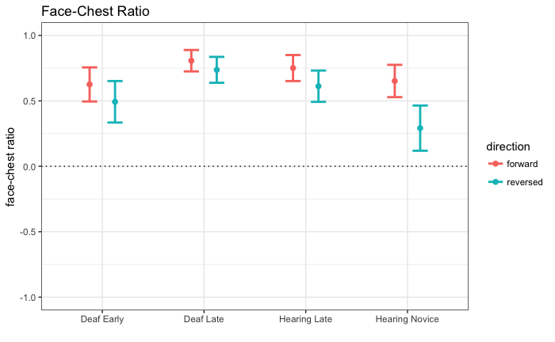

```r
facechest_info <- fulldata %>%
  filter(eye_exclude == FALSE) %>%
  group_by(maingroup, direction, participant) %>%
  summarise(facechest = mean(facechest, na.rm = TRUE)) %>%
  group_by(maingroup, direction) %>%
  summarise(mean = mean(facechest),
            sd = sd(facechest),
            n = n(),
            se = sd/sqrt(n)) %>%
  ungroup() %>%
  mutate(maingroup = case_when(
    maingroup == "DeafEarly" ~ "Deaf Early",
    maingroup == "DeafLate" ~ "Deaf Late",
    maingroup == "HearingLate" ~ "Hearing Late",
    maingroup == "HearingNovice" ~ "Hearing Novice"
    ))
ggplot(facechest_info, aes(x = maingroup, y = mean, fill = direction, color = direction)) +
  geom_point(stat = "identity", position = position_dodge(0.5), size = 2) +
  geom_errorbar(aes(ymin = mean-se, ymax = mean+se), position = position_dodge(0.5), width = 0.3, size = 1) +
  labs(title = "Face-Chest Ratio", x = "", y = "face-chest ratio") +
  scale_y_continuous(limits = c(-1,1)) +
  geom_hline(yintercept = 0, linetype = "dotted") +
  theme_bw()
```

Now let’s do the ANOVAs. Also skipping LSDs here.

1. ANOVA with factors MainGroup & Direction.

```
Grouping rowwise data frame strips rowwise natureConverting "id" to factor for ANOVA.Converting "direction" to factor for ANOVA.Converting "maingroup" to factor for ANOVA.Data is unbalanced (unequal N per group). Make sure you specified a well-considered value for the type argument to ezANOVA().
```

|  | Effect | DFn | DFd | F | p | p<.05 | ges |
| --- | --- | --- | --- | --- | --- | --- | --- |
| 2 | maingroup | 3 | 47 | 1.090178 | 0.3625388313 |  | 0.05892824 |
| 3 | direction | 1 | 47 | 17.750208 | 0.0001131687 | * | 0.03643736 |
| 4 | maingroup:direction | 3 | 47 | 2.361893 | 0.0832453282 |  | 0.01487093 |

```
NA
```

2. ANOVA with factor MainGroup, for Forward only.

```
Converting "id" to factor for ANOVA.Converting "maingroup" to factor for ANOVA.Data is unbalanced (unequal N per group). Make sure you specified a well-considered value for the type argument to ezANOVA().Coefficient covariances computed by hccm()
```

|  | Effect | DFn | DFd | F | p | p<.05 | ges |
| --- | --- | --- | --- | --- | --- | --- | --- |
| 2 | maingroup | 3 | 47 | 0.512618 | 0.6755604 |  | 0.0316836 |

```
NA
```

3. ANOVA with factor MainGroup, for Reverse only.

```
Converting "id" to factor for ANOVA.Converting "maingroup" to factor for ANOVA.Data is unbalanced (unequal N per group). Make sure you specified a well-considered value for the type argument to ezANOVA().Coefficient covariances computed by hccm()
```

|  | Effect | DFn | DFd | F | p | p<.05 | ges |
| --- | --- | --- | --- | --- | --- | --- | --- |
| 2 | maingroup | 3 | 47 | 1.6734 | 0.1854905 |  | 0.09650483 |

```
NA
```

# Eye Gaze & Performance Correlations

Next we’re going to correlate our eye gaze metrics (Eye, Mouth, Neck, and FaceChest) with lexical recall and gist. Okay! But remember we have a slightly smaller dataset here because we’ve excluded some participants for having bad eye data (but they had valid behavioral data so we kept them in the AoA-Performance correlations above).

**IMPORTANT: We also removed gist_forward column.**

```r
eyeperf <- fulldata %>%
  filter(eye_exclude == FALSE) %>%
  select(participant, maingroup, hearing, direction, aoasl, signyrs, selfrate, acc, gist, eyes, mouth, neck, facechest) %>%
  group_by(maingroup, participant, direction) %>%
  mutate(gist = mean(gist, na.rm = TRUE),
         lex = mean(acc, na.rm = TRUE),
         eyes = mean(eyes, na.rm = TRUE),
         mouth = mean(mouth, na.rm = TRUE),
         neck = mean(neck, na.rm = TRUE),
         facechest = mean(facechest, na.rm = TRUE)) %>%
  ungroup() %>%
  select(maingroup, participant, hearing, direction, aoasl, signyrs, selfrate, gist, lex, eyes, mouth, neck, facechest) %>%
  distinct() %>%
  gather(metric, value, gist:facechest) %>%
  unite(metricvalue, c(metric, direction), sep = "_") %>%
  spread(metricvalue, value) %>%
  select(-participant, -maingroup) %>%
  select(hearing, aoasl, signyrs, selfrate, gist_reversed, lex_forward, lex_reversed, eyes_forward,
         eyes_reversed, mouth_forward, mouth_reversed, neck_forward, neck_reversed,
         facechest_forward, facechest_reversed)
```

```
Grouping rowwise data frame strips rowwise nature
```

```r
eyeperf_deaf <- eyeperf %>% filter(hearing == "Deaf") %>% select(-hearing)
eyeperf_deaf_fw <- eyeperf_deaf %>% select(aoasl, signyrs, selfrate, lex_forward, eyes_forward,
                                           mouth_forward, neck_forward, facechest_forward)
eyeperf_deaf_rv <- eyeperf_deaf %>% select(aoasl, signyrs, selfrate, gist_reversed, lex_reversed,
                                           eyes_reversed, mouth_reversed, neck_reversed, facechest_reversed)
eyeperf_hearing <- eyeperf %>% filter(hearing == "Hearing") %>% select(-hearing)
eyeperf_hearing_fw <- eyeperf_hearing %>% select(aoasl, signyrs, selfrate, lex_forward, eyes_forward,
                                           mouth_forward, neck_forward, facechest_forward)
eyeperf_hearing_rv <- eyeperf_hearing %>% select(aoasl, signyrs, selfrate, gist_reversed, lex_reversed,
                                           eyes_reversed, mouth_reversed, neck_reversed, facechest_reversed)
eyeperf_all <- eyeperf %>% select(-hearing)
eyeperf_all_fw <- eyeperf_all %>% select(aoasl, signyrs, selfrate, lex_forward, eyes_forward,
                                           mouth_forward, neck_forward, facechest_forward)
eyeperf_all_rv <- eyeperf_all %>% select(aoasl, signyrs, selfrate, gist_reversed, lex_reversed,
                                           eyes_reversed, mouth_reversed, neck_reversed, facechest_reversed)
```

## Deaf Correlations, Forward

```r
# Correlations for Deaf
print("DEAF Correlations - Pearson's r")
```

```
[1] "DEAF Correlations - Pearson's r"
```

```r
#corstarsl(lexgist_deaf)
Hmisc::rcorr(as.matrix(eyeperf_deaf_fw))$r
```

```
NaNs produced
```

```
                       aoasl     signyrs selfrate lex_forward eyes_forward mouth_forward
aoasl              1.0000000 -0.50188271      NaN   0.1172403   0.06486300    0.17733161
signyrs           -0.5018827  1.00000000      NaN   0.3851766   0.08415829    0.09383576
selfrate                 NaN         NaN        1         NaN         -Inf           NaN
lex_forward        0.1172403  0.38517662      NaN   1.0000000   0.19560271    0.11273652
eyes_forward       0.0648630  0.08415829     -Inf   0.1956027   1.00000000   -0.40389579
mouth_forward      0.1773316  0.09383576      NaN   0.1127365  -0.40389579    1.00000000
neck_forward      -0.2393697 -0.13346320       NA  -0.2818220  -0.40213532   -0.66524894
facechest_forward  0.2500143  0.15009922      NaN   0.2796232   0.37868728    0.69180555
                  neck_forward facechest_forward
aoasl               -0.2393697         0.2500143
signyrs             -0.1334632         0.1500992
selfrate                    NA               NaN
lex_forward         -0.2818220         0.2796232
eyes_forward        -0.4021353         0.3786873
mouth_forward       -0.6652489         0.6918055
neck_forward         1.0000000        -0.9914181
facechest_forward   -0.9914181         1.0000000
```

```r
print("DEAF Correlations - P-values")
```

```
[1] "DEAF Correlations - P-values"
```

```r
Hmisc::rcorr(as.matrix(eyeperf_deaf_fw))$P
```

```
NaNs produced
```

```
                        aoasl     signyrs selfrate lex_forward eyes_forward mouth_forward
aoasl                      NA 0.005536859      NaN  0.54472642   0.73816410  3.574281e-01
signyrs           0.005536859          NA      NaN  0.03907661   0.66425765  6.282695e-01
selfrate                  NaN         NaN       NA         NaN          NaN           NaN
lex_forward       0.544726419 0.039076613      NaN          NA   0.30920842  5.603908e-01
eyes_forward      0.738164098 0.664257652      NaN  0.30920842           NA  2.978758e-02
mouth_forward     0.357428124 0.628269497      NaN  0.56039077   0.02978758            NA
neck_forward      0.211072773 0.490065695       NA  0.13857693   0.03057654  8.235939e-05
facechest_forward 0.190862019 0.437057253      NaN  0.14181412   0.04279115  3.228724e-05
                  neck_forward facechest_forward
aoasl             2.110728e-01      1.908620e-01
signyrs           4.900657e-01      4.370573e-01
selfrate                    NA               NaN
lex_forward       1.385769e-01      1.418141e-01
eyes_forward      3.057654e-02      4.279115e-02
mouth_forward     8.235939e-05      3.228724e-05
neck_forward                NA      0.000000e+00
facechest_forward 0.000000e+00                NA
```

```r
cat(paste("","\n",""))
```

```r
corstarsl(eyeperf_deaf_fw)
```

```
NaNs producedNaNs produced
```

|  | aoasl | signyrs | selfrate | lex_forward | eyes_forward | mouth_forward | neck_forward |
| --- | --- | --- | --- | --- | --- | --- | --- |
| aoasl |  |  |  |  |  |  |  |
| signyrs | -0.50** |  |  |  |  |  |  |
| selfrate | NaNNA | NaNNA |  |  |  |  |  |
| lex_forward | 0.12 | 0.39* | NaNNA |  |  |  |  |
| eyes_forward | 0.06 | 0.08 | -InfNA | 0.20 |  |  |  |
| mouth_forward | 0.18 | 0.09 | NaNNA | 0.11 | -0.40* |  |  |
| neck_forward | -0.24 | -0.13 | NANA | -0.28 | -0.40* | -0.67*** |  |
| facechest_forward | 0.25 | 0.15 | NaNNA | 0.28 | 0.38* | 0.69*** | -0.99*** |

## Deaf Correlations, Reversed

```r
# Correlations for Deaf
print("DEAF Correlations - Pearson's r")
```

```
[1] "DEAF Correlations - Pearson's r"
```

```r
#corstarsl(lexgist_deaf)
Hmisc::rcorr(as.matrix(eyeperf_deaf_rv))$r
```

```
NaNs produced
```

```
                         aoasl      signyrs selfrate gist_reversed lex_reversed eyes_reversed
aoasl               1.00000000 -0.501882714      NaN   -0.22660857  -0.16780060    0.02247978
signyrs            -0.50188271  1.000000000      NaN   -0.10665206  -0.02521081    0.09583660
selfrate                   NaN          NaN        1           NaN         -Inf          -Inf
gist_reversed      -0.22660857 -0.106652058      NaN    1.00000000   0.30316904    0.02254099
lex_reversed       -0.16780060 -0.025210812     -Inf    0.30316904   1.00000000   -0.07989084
eyes_reversed       0.02247978  0.095836598     -Inf    0.02254099  -0.07989084    1.00000000
mouth_reversed      0.30344566  0.007193105       NA    0.06590947   0.11828487   -0.45147688
neck_reversed      -0.32970389 -0.052028484      NaN   -0.07553298  -0.01236973   -0.42235608
facechest_reversed  0.30789805  0.086108174      NaN    0.08644925   0.03749679    0.43328831
                   mouth_reversed neck_reversed facechest_reversed
aoasl                 0.303445656   -0.32970389         0.30789805
signyrs               0.007193105   -0.05202848         0.08610817
selfrate                       NA           NaN                NaN
gist_reversed         0.065909471   -0.07553298         0.08644925
lex_reversed          0.118284868   -0.01236973         0.03749679
eyes_reversed        -0.451476879   -0.42235608         0.43328831
mouth_reversed        1.000000000   -0.59771759         0.59842561
neck_reversed        -0.597717586    1.00000000        -0.99196123
facechest_reversed    0.598425615   -0.99196123         1.00000000
```

```r
print("DEAF Correlations - P-values")
```

```
[1] "DEAF Correlations - P-values"
```

```r
Hmisc::rcorr(as.matrix(eyeperf_deaf_rv))$P
```

```
NaNs produced
```

```
                         aoasl     signyrs selfrate gist_reversed lex_reversed eyes_reversed
aoasl                       NA 0.005536859      NaN     0.2462148    0.3933761    0.90960039
signyrs            0.005536859          NA      NaN     0.5890837    0.8986706    0.62759255
selfrate                   NaN         NaN       NA           NaN          NaN           NaN
gist_reversed      0.246214837 0.589083651      NaN            NA    0.1168233    0.90935522
lex_reversed       0.393376109 0.898670598      NaN     0.1168233           NA    0.68612755
eyes_reversed      0.909600388 0.627592554      NaN     0.9093552    0.6861276            NA
mouth_reversed     0.116473238 0.971021336       NA     0.7389667    0.5488535    0.01588231
neck_reversed      0.086644303 0.792600789      NaN     0.7024561    0.9501866    0.02515937
facechest_reversed 0.110944277 0.663069853      NaN     0.6618134    0.8497523    0.02126289
                   mouth_reversed neck_reversed facechest_reversed
aoasl                0.1164732376  0.0866443030       0.1109442772
signyrs              0.9710213364  0.7926007893       0.6630698529
selfrate                       NA           NaN                NaN
gist_reversed        0.7389667101  0.7024561485       0.6618133668
lex_reversed         0.5488534905  0.9501865707       0.8497522839
eyes_reversed        0.0158823144  0.0251593655       0.0212628885
mouth_reversed                 NA  0.0007826591       0.0007685907
neck_reversed        0.0007826591            NA       0.0000000000
facechest_reversed   0.0007685907  0.0000000000                 NA
```

```r
cat(paste("","\n",""))
```

```r
corstarsl(eyeperf_deaf_rv)
```

```
NaNs producedNaNs produced
```

|  | aoasl | signyrs | selfrate | gist_reversed | lex_reversed | eyes_reversed | mouth_reversed | neck_reversed |
| --- | --- | --- | --- | --- | --- | --- | --- | --- |
| aoasl |  |  |  |  |  |  |  |  |
| signyrs | -0.50** |  |  |  |  |  |  |  |
| selfrate | NaNNA | NaNNA |  |  |  |  |  |  |
| gist_reversed | -0.23 | -0.11 | NaNNA |  |  |  |  |  |
| lex_reversed | -0.17 | -0.03 | -InfNA | 0.30 |  |  |  |  |
| eyes_reversed | 0.02 | 0.10 | -InfNA | 0.02 | -0.08 |  |  |  |
| mouth_reversed | 0.30 | 0.01 | NANA | 0.07 | 0.12 | -0.45* |  |  |
| neck_reversed | -0.33 | -0.05 | NaNNA | -0.08 | -0.01 | -0.42* | -0.60*** |  |
| facechest_reversed | 0.31 | 0.09 | NaNNA | 0.09 | 0.04 | 0.43* | 0.60*** | -0.99*** |

## Hearing Correlations, Forward

```r
# Correlations for Hearing
print("HEARING Correlations - Pearson's r")
```

```
[1] "HEARING Correlations - Pearson's r"
```

```r
#corstarsl(lexgist_hearing)
Hmisc::rcorr(as.matrix(eyeperf_hearing_fw))$r
```

```
                        aoasl     signyrs     selfrate lex_forward eyes_forward mouth_forward
aoasl              1.00000000 -0.07887014  0.013855614  0.08908095 -0.311357174    0.17806747
signyrs           -0.07887014  1.00000000  0.738478512  0.26130640  0.132498229    0.06609089
selfrate           0.01385561  0.73847851  1.000000000  0.47076831  0.003272703   -0.03631110
lex_forward        0.08908095  0.26130640  0.470768307  1.00000000 -0.206412381    0.04471778
eyes_forward      -0.31135717  0.13249823  0.003272703 -0.20641238  1.000000000   -0.75736409
mouth_forward      0.17806747  0.06609089 -0.036311096  0.04471778 -0.757364090    1.00000000
neck_forward       0.38414940 -0.24596133  0.135873662  0.36551587 -0.547841416   -0.08094060
facechest_forward -0.28903425  0.30186427 -0.017766369 -0.28030958  0.532841135    0.14471392
                  neck_forward facechest_forward
aoasl                0.3841494       -0.28903425
signyrs             -0.2459613        0.30186427
selfrate             0.1358737       -0.01776637
lex_forward          0.3655159       -0.28030958
eyes_forward        -0.5478414        0.53284113
mouth_forward       -0.0809406        0.14471392
neck_forward         1.0000000       -0.94241622
facechest_forward   -0.9424162        1.00000000
```

```r
print("HEARING Correlations - P-values")
```

```
[1] "HEARING Correlations - P-values"
```

```r
Hmisc::rcorr(as.matrix(eyeperf_hearing_fw))$P
```

```
                       aoasl      signyrs     selfrate lex_forward eyes_forward mouth_forward
aoasl                     NA 0.7205586083 0.9499685271  0.68606710 1.481267e-01  4.162839e-01
signyrs           0.72055861           NA 0.0000573213  0.22845065 5.467283e-01  7.644727e-01
selfrate          0.94996853 0.0000573213           NA  0.02337677 9.881758e-01  8.693499e-01
lex_forward       0.68606710 0.2284506503 0.0233767693          NA 3.446870e-01  8.394476e-01
eyes_forward      0.14812668 0.5467283190 0.9881757567  0.34468695           NA  2.859607e-05
mouth_forward     0.41628385 0.7644726750 0.8693498612  0.83944756 2.859607e-05            NA
neck_forward      0.07033577 0.2579308336 0.5364660663  0.08632259 6.807339e-03  7.135194e-01
facechest_forward 0.18102107 0.1615536596 0.9358722215  0.19514550 8.849714e-03  5.100229e-01
                  neck_forward facechest_forward
aoasl             7.033577e-02      1.810211e-01
signyrs           2.579308e-01      1.615537e-01
selfrate          5.364661e-01      9.358722e-01
lex_forward       8.632259e-02      1.951455e-01
eyes_forward      6.807339e-03      8.849714e-03
mouth_forward     7.135194e-01      5.100229e-01
neck_forward                NA      1.861311e-11
facechest_forward 1.861311e-11                NA
```

```r
cat(paste("","\n",""))
```

```r
corstarsl(eyeperf_hearing_fw)
```

|  | aoasl | signyrs | selfrate | lex_forward | eyes_forward | mouth_forward | neck_forward |
| --- | --- | --- | --- | --- | --- | --- | --- |
| aoasl |  |  |  |  |  |  |  |
| signyrs | -0.08 |  |  |  |  |  |  |
| selfrate | 0.01 | 0.74*** |  |  |  |  |  |
| lex_forward | 0.09 | 0.26 | 0.47* |  |  |  |  |
| eyes_forward | -0.31 | 0.13 | 0.00 | -0.21 |  |  |  |
| mouth_forward | 0.18 | 0.07 | -0.04 | 0.04 | -0.76*** |  |  |
| neck_forward | 0.38 | -0.25 | 0.14 | 0.37 | -0.55** | -0.08 |  |
| facechest_forward | -0.29 | 0.30 | -0.02 | -0.28 | 0.53** | 0.14 | -0.94*** |

## Hearing Correlations, Reversed

```r
# Correlations for Hearing
print("HEARING Correlations - Pearson's r")
```

```
[1] "HEARING Correlations - Pearson's r"
```

```r
#corstarsl(lexgist_hearing)
Hmisc::rcorr(as.matrix(eyeperf_hearing_rv))$r
```

```
                         aoasl     signyrs    selfrate gist_reversed lex_reversed eyes_reversed
aoasl               1.00000000 -0.07887014  0.01385561   0.078157516   0.06994866  -0.234574150
signyrs            -0.07887014  1.00000000  0.73847851   0.288457469   0.22209268   0.306984046
selfrate            0.01385561  0.73847851  1.00000000   0.521440792   0.36876982   0.192505548
gist_reversed       0.07815752  0.28845747  0.52144079   1.000000000   0.61989299  -0.003896107
lex_reversed        0.06994866  0.22209268  0.36876982   0.619892993   1.00000000  -0.128554235
eyes_reversed      -0.23457415  0.30698405  0.19250555  -0.003896107  -0.12855424   1.000000000
mouth_reversed      0.06256448  0.04730903 -0.11038394  -0.057827989   0.01769965  -0.608459497
neck_reversed       0.29446186 -0.38249551 -0.08287913   0.223993634   0.24863579  -0.667670003
facechest_reversed -0.20474471  0.43157928  0.15951977  -0.163039205  -0.19097043   0.602644558
                   mouth_reversed neck_reversed facechest_reversed
aoasl                  0.06256448    0.29446186         -0.2047447
signyrs                0.04730903   -0.38249551          0.4315793
selfrate              -0.11038394   -0.08287913          0.1595198
gist_reversed         -0.05782799    0.22399363         -0.1630392
lex_reversed           0.01769965    0.24863579         -0.1909704
eyes_reversed         -0.60845950   -0.66767000          0.6026446
mouth_reversed         1.00000000   -0.09060995          0.2372879
neck_reversed         -0.09060995    1.00000000         -0.9351352
facechest_reversed     0.23728789   -0.93513523          1.0000000
```

```r
print("HEARING Correlations - P-values")
```

```
[1] "HEARING Correlations - P-values"
```

```r
Hmisc::rcorr(as.matrix(eyeperf_hearing_rv))$P
```

```
                       aoasl      signyrs     selfrate gist_reversed lex_reversed eyes_reversed
aoasl                     NA 0.7205586083 0.9499685271   0.722986491  0.751135019  0.2813176833
signyrs            0.7205586           NA 0.0000573213   0.181932485  0.308433961  0.1542103596
selfrate           0.9499685 0.0000573213           NA   0.010720159  0.083351365  0.3788529950
gist_reversed      0.7229865 0.1819324846 0.0107201595            NA  0.001604979  0.9859236041
lex_reversed       0.7511350 0.3084339611 0.0833513648   0.001604979           NA  0.5588319770
eyes_reversed      0.2813177 0.1542103596 0.3788529950   0.985923604  0.558831977            NA
mouth_reversed     0.7767217 0.8302717357 0.6160911892   0.793254788  0.936112582  0.0020651929
neck_reversed      0.1725980 0.0716562063 0.7069492591   0.304204161  0.252625006  0.0004996114
facechest_reversed 0.3486849 0.0397532848 0.4671998551   0.457300302  0.382738853  0.0023393018
                   mouth_reversed neck_reversed facechest_reversed
aoasl                 0.776721714  1.725980e-01       3.486849e-01
signyrs               0.830271736  7.165621e-02       3.975328e-02
selfrate              0.616091189  7.069493e-01       4.671999e-01
gist_reversed         0.793254788  3.042042e-01       4.573003e-01
lex_reversed          0.936112582  2.526250e-01       3.827389e-01
eyes_reversed         0.002065193  4.996114e-04       2.339302e-03
mouth_reversed                 NA  6.809520e-01       2.756271e-01
neck_reversed         0.680952034            NA       6.290390e-11
facechest_reversed    0.275627132  6.290390e-11                 NA
```

```r
cat(paste("","\n",""))
```

```r
corstarsl(eyeperf_hearing_rv)
```

|  | aoasl | signyrs | selfrate | gist_reversed | lex_reversed | eyes_reversed | mouth_reversed | neck_reversed |
| --- | --- | --- | --- | --- | --- | --- | --- | --- |
| aoasl |  |  |  |  |  |  |  |  |
| signyrs | -0.08 |  |  |  |  |  |  |  |
| selfrate | 0.01 | 0.74*** |  |  |  |  |  |  |
| gist_reversed | 0.08 | 0.29 | 0.52* |  |  |  |  |  |
| lex_reversed | 0.07 | 0.22 | 0.37 | 0.62** |  |  |  |  |
| eyes_reversed | -0.23 | 0.31 | 0.19 | 0.00 | -0.13 |  |  |  |
| mouth_reversed | 0.06 | 0.05 | -0.11 | -0.06 | 0.02 | -0.61** |  |  |
| neck_reversed | 0.29 | -0.38 | -0.08 | 0.22 | 0.25 | -0.67*** | -0.09 |  |
| facechest_reversed | -0.20 | 0.43* | 0.16 | -0.16 | -0.19 | 0.60** | 0.24 | -0.94*** |

## All People Correlations, Forward

```r
eyeperf_fwrv <- fulldata %>%
  filter(eye_exclude == FALSE) %>%
  select(participant, maingroup, hearing, direction, aoasl, signyrs, selfrate, acc, gist, eyes, mouth, neck, facechest) %>%
  group_by(maingroup, participant, direction) %>%
  mutate(gist = mean(gist, na.rm = TRUE),
         lex = mean(acc, na.rm = TRUE),
         eyes = mean(eyes, na.rm = TRUE),
         mouth = mean(mouth, na.rm = TRUE),
         neck = mean(neck, na.rm = TRUE),
         facechest = mean(facechest, na.rm = TRUE)) %>%
  ungroup() %>%
  select(maingroup, participant, hearing, direction, aoasl, signyrs, selfrate, gist, lex, eyes, mouth, neck, facechest) %>%
  distinct() %>%
  gather(metric, value, gist:facechest) %>%
  unite(metricvalue, c(metric, direction), sep = "_", remove = FALSE) %>%
  select(-metric) %>%
  spread(metricvalue, value) %>%
  select(-participant, -maingroup, -hearing) %>%
  select(direction, aoasl, signyrs, selfrate, gist_reversed, lex_forward, lex_reversed, eyes_forward, eyes_reversed,
         mouth_forward, mouth_reversed, neck_forward, neck_reversed, facechest_forward, facechest_reversed)
```

```
Grouping rowwise data frame strips rowwise nature
```

```r
eyeperf_fw <- eyeperf_fwrv %>% filter(direction == "forward") %>%
  select(-direction, -gist_reversed, -lex_reversed, -eyes_reversed, -mouth_reversed, -neck_reversed, -facechest_reversed)
eyeperf_rv <- eyeperf_fwrv %>% filter(direction == "reversed") %>% select(-direction, -lex_forward, -eyes_forward, -mouth_forward, -neck_forward, -facechest_forward)
# Correlations for FW
print("FW Correlations - Pearson's r")
```

```
[1] "FW Correlations - Pearson's r"
```

```r
#corstarsl(lexgist_deaf)
Hmisc::rcorr(as.matrix(eyeperf_fw))$r
```

```
                        aoasl     signyrs      selfrate lex_forward eyes_forward mouth_forward
aoasl              1.00000000 -0.78522450 -0.5061627801 -0.14263169    0.1023350    -0.0600452
signyrs           -0.78522450  1.00000000  0.7095934161  0.36334718   -0.0971436     0.2172435
selfrate          -0.50616278  0.70959342  1.0000000000  0.46112439   -0.1184349     0.1191126
lex_forward       -0.14263169  0.36334718  0.4611243862  1.00000000   -0.1346806     0.1166878
eyes_forward       0.10233497 -0.09714360 -0.1184348559 -0.13468058    1.0000000    -0.6230710
mouth_forward     -0.06004520  0.21724346  0.1191126408  0.11668783   -0.6230710     1.0000000
neck_forward      -0.12643634 -0.03886278  0.0937957291  0.05166907   -0.4273280    -0.4048121
facechest_forward  0.06745102  0.12098148 -0.0001684626 -0.03165485    0.4281833     0.4368729
                  neck_forward facechest_forward
aoasl              -0.12643634      0.0674510168
signyrs            -0.03886278      0.1209814757
selfrate            0.09379573     -0.0001684626
lex_forward         0.05166907     -0.0316548545
eyes_forward       -0.42732804      0.4281833073
mouth_forward      -0.40481211      0.4368729235
neck_forward        1.00000000     -0.9653761042
facechest_forward  -0.96537610      1.0000000000
```

```r
print("FW Correlations - P-values")
```

```
[1] "FW Correlations - P-values"
```

```r
Hmisc::rcorr(as.matrix(eyeperf_fw))$P
```

```
                         aoasl      signyrs     selfrate  lex_forward eyes_forward
aoasl                       NA 5.523138e-12 1.290502e-04 0.3131194308 4.703512e-01
signyrs           5.523138e-12           NA 3.880305e-09 0.0081064913 4.932766e-01
selfrate          1.290502e-04 3.880305e-09           NA 0.0005807582 4.030234e-01
lex_forward       3.131194e-01 8.106491e-03 5.807582e-04           NA 3.411309e-01
eyes_forward      4.703512e-01 4.932766e-01 4.030234e-01 0.3411308761           NA
mouth_forward     6.724059e-01 1.218575e-01 4.003178e-01 0.4100459246 8.097560e-07
neck_forward      3.717642e-01 7.844425e-01 5.083628e-01 0.7160246926 1.579677e-03
facechest_forward 6.347056e-01 3.929129e-01 9.990543e-01 0.8237119972 1.542092e-03
                  mouth_forward neck_forward facechest_forward
aoasl              6.724059e-01  0.371764201       0.634705650
signyrs            1.218575e-01  0.784442484       0.392912900
selfrate           4.003178e-01  0.508362784       0.999054292
lex_forward        4.100459e-01  0.716024693       0.823711997
eyes_forward       8.097560e-07  0.001579677       0.001542092
mouth_forward                NA  0.002913236       0.001203117
neck_forward       2.913236e-03           NA       0.000000000
facechest_forward  1.203117e-03  0.000000000                NA
```

```r
cat(paste("","\n",""))
```

```r
corstarsl(eyeperf_fw)
```

|  | aoasl | signyrs | selfrate | lex_forward | eyes_forward | mouth_forward | neck_forward |
| --- | --- | --- | --- | --- | --- | --- | --- |
| aoasl |  |  |  |  |  |  |  |
| signyrs | -0.79*** |  |  |  |  |  |  |
| selfrate | -0.51*** | 0.71*** |  |  |  |  |  |
| lex_forward | -0.14 | 0.36** | 0.46*** |  |  |  |  |
| eyes_forward | 0.10 | -0.10 | -0.12 | -0.13 |  |  |  |
| mouth_forward | -0.06 | 0.22 | 0.12 | 0.12 | -0.62*** |  |  |
| neck_forward | -0.13 | -0.04 | 0.09 | 0.05 | -0.43** | -0.40** |  |
| facechest_forward | 0.07 | 0.12 | 0.00 | -0.03 | 0.43** | 0.44** | -0.97*** |

## All People Correlations, Reversed

```r
# Correlations for RV
print("RV Correlations - Pearson's r")
```

```
[1] "RV Correlations - Pearson's r"
```

```r
#corstarsl(lexgist_hearing)
Hmisc::rcorr(as.matrix(eyeperf_rv))$r
```

```
                          aoasl     signyrs    selfrate gist_reversed lex_reversed
aoasl               1.000000000 -0.78501877 -0.50422978 -0.3232638330  -0.25779732
signyrs            -0.785018765  1.00000000  0.70727052  0.2341087663   0.24984565
selfrate           -0.504229778  0.70727052  1.00000000  0.3761505176   0.35782852
gist_reversed      -0.323263833  0.23410877  0.37615052  1.0000000000   0.44831458
lex_reversed       -0.257797316  0.24984565  0.35782852  0.4483145836   1.00000000
eyes_reversed       0.083660505 -0.02729735  0.01126565 -0.0331474583  -0.14027902
mouth_reversed     -0.086016858  0.25058312  0.13689724  0.1034677946   0.14056188
neck_reversed      -0.094361911 -0.11454842 -0.05930558 -0.0002581996   0.07954129
facechest_reversed -0.006715593  0.23324074  0.17394754  0.0425947142  -0.02840231
                   eyes_reversed mouth_reversed neck_reversed facechest_reversed
aoasl                 0.08366050    -0.08601686 -0.0943619107       -0.006715593
signyrs              -0.02729735     0.25058312 -0.1145484173        0.233240744
selfrate              0.01126565     0.13689724 -0.0593055817        0.173947537
gist_reversed        -0.03314746     0.10346779 -0.0002581996        0.042594714
lex_reversed         -0.14027902     0.14056188  0.0795412921       -0.028402311
eyes_reversed         1.00000000    -0.54427342 -0.5032187287        0.482238920
mouth_reversed       -0.54427342     1.00000000 -0.3897527180        0.454607280
neck_reversed        -0.50321873    -0.38975272  1.0000000000       -0.957692723
facechest_reversed    0.48223892     0.45460728 -0.9576927231        1.000000000
```

```r
print("RV Correlations - P-values")
```

```
[1] "RV Correlations - P-values"
```

```r
Hmisc::rcorr(as.matrix(eyeperf_rv))$P
```

```
                          aoasl      signyrs     selfrate gist_reversed lex_reversed
aoasl                        NA 9.197088e-12 1.615663e-04  0.0206764678 0.0677889947
signyrs            9.197088e-12           NA 6.557450e-09  0.0982310702 0.0770305455
selfrate           1.615663e-04 6.557450e-09           NA  0.0065211919 0.0099363454
gist_reversed      2.067647e-02 9.823107e-02 6.521192e-03            NA 0.0009694894
lex_reversed       6.778899e-02 7.703055e-02 9.936345e-03  0.0009694894           NA
eyes_reversed      5.594433e-01 8.491958e-01 9.374615e-01  0.8173808170 0.3261871603
mouth_reversed     5.483940e-01 7.613368e-02 3.381006e-01  0.4699673753 0.3252028489
neck_reversed      5.101240e-01 4.234798e-01 6.793201e-01  0.9985652449 0.5790065420
facechest_reversed 9.626962e-01 9.952015e-02 2.221732e-01  0.7666339762 0.8431667739
                   eyes_reversed mouth_reversed neck_reversed facechest_reversed
aoasl               5.594433e-01   5.483940e-01  0.5101239880       0.9626961679
signyrs             8.491958e-01   7.613368e-02  0.4234797598       0.0995201469
selfrate            9.374615e-01   3.381006e-01  0.6793201353       0.2221731688
gist_reversed       8.173808e-01   4.699674e-01  0.9985652449       0.7666339762
lex_reversed        3.261872e-01   3.252028e-01  0.5790065420       0.8431667739
eyes_reversed                 NA   3.651373e-05  0.0001673547       0.0003391156
mouth_reversed      3.651373e-05             NA  0.0046967183       0.0008043284
neck_reversed       1.673547e-04   4.696718e-03            NA       0.0000000000
facechest_reversed  3.391156e-04   8.043284e-04  0.0000000000                 NA
```

```r
cat(paste("","\n",""))
```

```r
corstarsl(eyeperf_rv)
```

|  | aoasl | signyrs | selfrate | gist_reversed | lex_reversed | eyes_reversed | mouth_reversed | neck_reversed |
| --- | --- | --- | --- | --- | --- | --- | --- | --- |
| aoasl |  |  |  |  |  |  |  |  |
| signyrs | -0.79*** |  |  |  |  |  |  |  |
| selfrate | -0.50*** | 0.71*** |  |  |  |  |  |  |
| gist_reversed | -0.32* | 0.23 | 0.38** |  |  |  |  |  |
| lex_reversed | -0.26 | 0.25 | 0.36** | 0.45*** |  |  |  |  |
| eyes_reversed | 0.08 | -0.03 | 0.01 | -0.03 | -0.14 |  |  |  |
| mouth_reversed | -0.09 | 0.25 | 0.14 | 0.10 | 0.14 | -0.54*** |  |  |
| neck_reversed | -0.09 | -0.11 | -0.06 | 0.00 | 0.08 | -0.50*** | -0.39** |  |
| facechest_reversed | -0.01 | 0.23 | 0.17 | 0.04 | -0.03 | 0.48*** | 0.45*** | -0.96*** |

## Correlation Table

And the correlation table.

[output not shown]

[output cut: 89 more lines]

[output not shown]

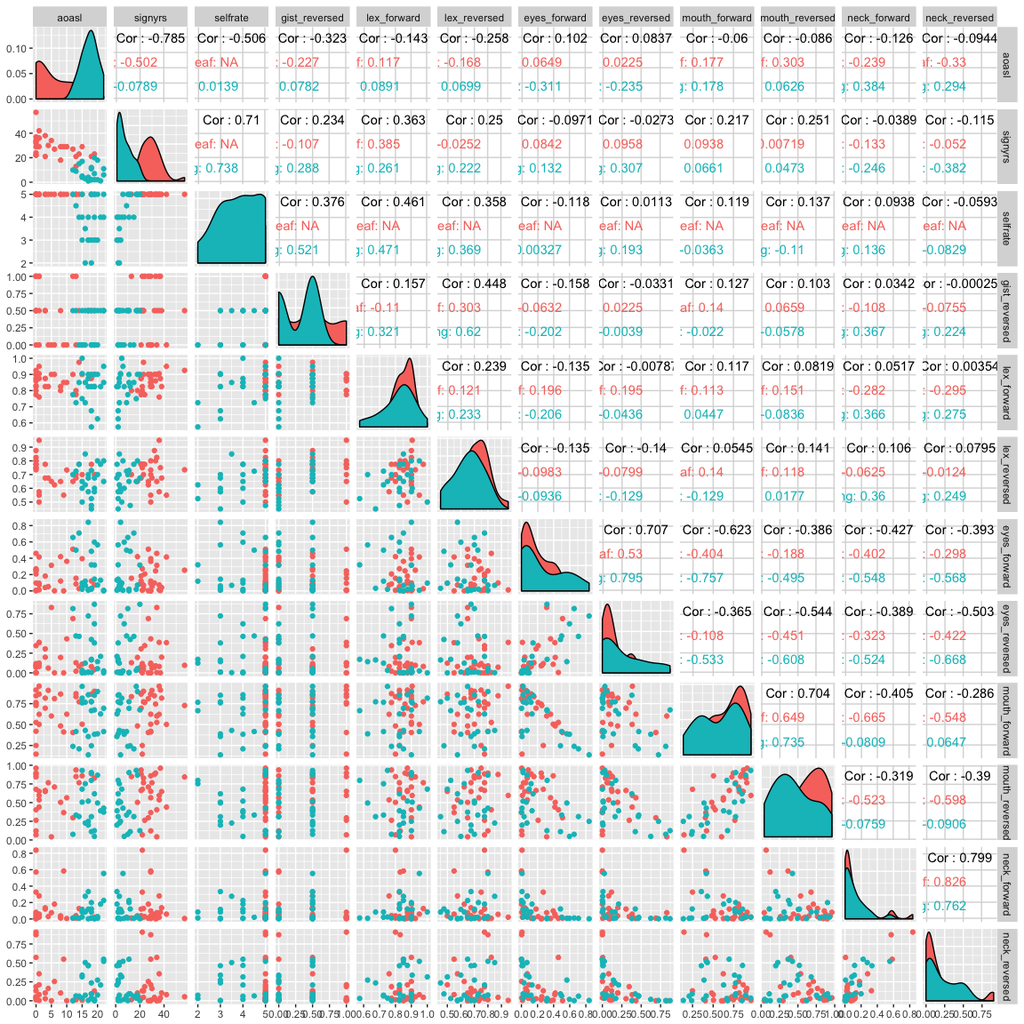

```r
ggpairs(eyeperf, columns = c(2:13), aes(color = hearing))
```

# Heat Maps

And finally, we’re going to do heat maps.

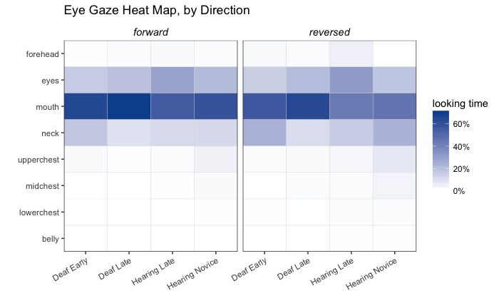

```r
eyegaze_heat <- fulldata %>%
  ungroup() %>%
  filter(eye_exclude == FALSE) %>%
  select(id:direction, belly, lowerchest, midchest, upperchest, neck, mouth, eyes, forehead) %>%
  gather(aoi, percent, belly:forehead) %>%
  group_by(maingroup, participant, direction, aoi) %>%
  summarise(percent = mean(percent, na.rm=TRUE)) %>%
  group_by(maingroup,direction,aoi) %>%
  summarise(percent = mean(percent, na.rm=TRUE)) %>%
  ungroup() %>%
  filter(!is.na(aoi)) %>%
  mutate(aoi = factor(aoi,levels=c("belly","lowerchest","midchest",
                                   "upperchest","neck","mouth","eyes","forehead"))) %>%
  ungroup() %>%
  mutate(maingroup = case_when(
    maingroup == "DeafEarly" ~ "Deaf Early",
    maingroup == "DeafLate" ~ "Deaf Late",
    maingroup == "HearingLate" ~ "Hearing Late",
    maingroup == "HearingNovice" ~ "Hearing Novice"
    ))
eyegaze_heat_all <- fulldata %>%
  ungroup() %>%
  filter(eye_exclude == FALSE) %>%
  select(id:direction, belly, lowerchest, midchest, upperchest, neck, mouth, eyes, forehead) %>%
  gather(aoi, percent, belly:forehead) %>%
  group_by(maingroup,participant,direction,aoi) %>%
  dplyr::summarize(percent = mean(percent, na.rm=TRUE)) %>%
  group_by(maingroup,direction,aoi) %>%
  dplyr::summarize(percent = mean(percent, na.rm=TRUE)) %>%
  group_by(maingroup,aoi) %>%
  dplyr::summarize(percent = mean(percent, na.rm=TRUE)) %>%
  ungroup() %>%
  filter(!is.na(aoi)) %>%
  mutate(aoi = factor(aoi,levels=c("belly","lowerchest","midchest",
                                   "upperchest","neck","mouth","eyes","forehead"))) %>%
  ungroup() %>%
  mutate(maingroup = case_when(
    maingroup == "DeafEarly" ~ "Deaf Early",
    maingroup == "DeafLate" ~ "Deaf Late",
    maingroup == "HearingLate" ~ "Hearing Late",
    maingroup == "HearingNovice" ~ "Hearing Novice"
    ))
ggplot(eyegaze_heat, aes(x = maingroup, y = aoi)) +
  geom_tile(aes(fill=percent),color="lightgray",na.rm=TRUE) +
#  scale_fill_viridis(option = "viridis", direction=-1, limits = c(0,.7), labels = percent, name = "looking time") +
    scale_fill_gradient(low = "#ffffff", high = "#08519c", space = "Lab", limits = c(0,.704), labels = percent, name = "looking time", na.value = "grey50") +
  theme_bw() +
  theme(axis.text.x=element_text(angle=30,hjust=1),
        strip.text.x = element_text(size = 11, color = "black", face = "italic"),
        strip.background = element_rect(colour = "white", fill = "white"),
        panel.grid.major = element_line(color = "white")) +
  facet_grid(. ~ direction) +
  ylab("") + xlab("") + ggtitle("Eye Gaze Heat Map, by Direction") +
  scale_y_discrete(expand=c(0,0)) +
  scale_x_discrete(expand = c(0,0))
```

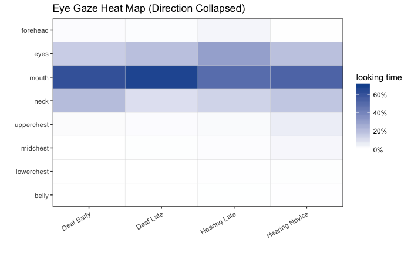

```r
ggplot(eyegaze_heat_all, aes(x = maingroup, y = aoi)) +
  geom_tile(aes(fill=percent),color="lightgray",na.rm=TRUE) +
#  scale_fill_distiller(palette = "Blues", direction=1, limits = c(0,.71), labels = percent, name = "looking time") +
  scale_fill_gradient(low = "#ffffff", high = "#08519c", space = "Lab", limits = c(0,.71), labels = percent, name = "looking time", na.value = "grey50") +
  theme_bw() +
  theme(axis.text.x=element_text(angle=30,hjust=1),
  panel.grid.major = element_line(color = "white")) +
  ylab("") + xlab("") + ggtitle("Eye Gaze Heat Map (Direction Collapsed)") +
  scale_y_discrete(expand=c(0,0)) +
  scale_x_discrete(expand=c(0,0))
```

# Summary

```r
results1 <- structure(list(model = c("gist-maingroup-both", "gist-maingroup-fw",
"gist-maingroup-rv", "lexrecall-maingroup-both", "lexrecall-maingroup-fw",
"lexrecall-maingroup-rv", "mouth-maingroup-both", "upperchest-maingroup-both",
"upperchest-maingroup-rv", "facechest-maingroup-both", "moutheye-maingroup-both"
), maingroup = c(0, 0, 0.01, 0, 0.04, 0.02, 0.06, 0, 0.01, 0.1,
0.05), direction = c(0, NA, NA, 0, NA, NA, 0.06, 0.16, NA, 0.07,
0.48), `deafearly-deaflate` = c(0.1, 0.69, 0.02, 0.11, 0.95,
0.06, 0.38, 0.94, 0.52, 0.08, 0.68)), .Names = c("model", "maingroup",
"direction", "deafearly-deaflate"), class = c("tbl_df", "tbl",
"data.frame"), row.names = c(NA, -11L))
results1
```

| model | maingroup | direction | deafearly-deaflate |
| --- | --- | --- | --- |
| gist-maingroup-both | 0.00 | 0.00 | 0.10 |
| gist-maingroup-fw | 0.00 | NA | 0.69 |
| gist-maingroup-rv | 0.01 | NA | 0.02 |
| lexrecall-maingroup-both | 0.00 | 0.00 | 0.11 |
| lexrecall-maingroup-fw | 0.04 | NA | 0.95 |
| lexrecall-maingroup-rv | 0.02 | NA | 0.06 |
| mouth-maingroup-both | 0.06 | 0.06 | 0.38 |
| upperchest-maingroup-both | 0.00 | 0.16 | 0.94 |
| upperchest-maingroup-rv | 0.01 | NA | 0.52 |
| facechest-maingroup-both | 0.10 | 0.07 | 0.08 |

[output cut: 1 more lines]

```r
results2 <- structure(list(model = c("gist-both", "gist-fw", "gist-rv", "lex-both",
"lex-fw", "lex-rv", "forehead-fw", "mouth-both", "mouth-rv",
"upperchest-both", "upperchest-rv", "facechest-both", "moutheye-both"
), hearing = c(0, 0.00, 0.01, 0.01, 0.22, 0.03, 0.06, 0.01,
0.04, 0.01, 0.01, 0.35, 0.07), direction = c(0, NA, NA, 0, NA,
NA, NA, 0.05, NA, 0.21, NA, 0.05, 0.52), aoasl = c(0.22, 0.77,
0.19, 0.56, 0.58, 0.25, 0.08, 0.06, 0.12, 0.68, 0.95, 0.12, 0.44
), age = c(0.08, 0.01, 0.86, 0.09, 0.02, 0.7, 0.68, 0.28, 0.5,
0.02, 0.08, 0.00, 0.21)), .Names = c("model", "hearing", "direction",
"aoasl", "age"), class = c("tbl_df", "tbl", "data.frame"), row.names = c(NA,
-13L))
results2
```

| model | hearing | direction | aoasl | age |
| --- | --- | --- | --- | --- |
| gist-both | 0.00 | 0.00 | 0.22 | 0.08 |
| gist-fw | 0.00 | NA | 0.77 | 0.01 |
| gist-rv | 0.01 | NA | 0.19 | 0.86 |
| lex-both | 0.01 | 0.00 | 0.56 | 0.09 |
| lex-fw | 0.22 | NA | 0.58 | 0.02 |
| lex-rv | 0.03 | NA | 0.25 | 0.70 |
| forehead-fw | 0.06 | NA | 0.08 | 0.68 |
| mouth-both | 0.01 | 0.05 | 0.06 | 0.28 |
| mouth-rv | 0.04 | NA | 0.12 | 0.50 |
| upperchest-both | 0.01 | 0.21 | 0.68 | 0.02 |

[output cut: 3 more lines]

Finally, the correlations for Deaf and Hearing separately are not significant. But there are significant correlations across all participants. I worry it is caused by HearingNovice, though…

```r
results3 <- tribble(
  ~ metric, ~ AoASLcorrelationRvalue, ~ Pvalue,
  "gist-fw", -0.32, 0.019,
  "gist-rv", -0.39, 0.004,
  "lex-fw", -0.08, 0.567,
  "lex-rv", -0.34, 0.014
)
results3
```

[output not shown]

# Ternary Plots

Let’s make triangle plots. “What?” you say. Read on.

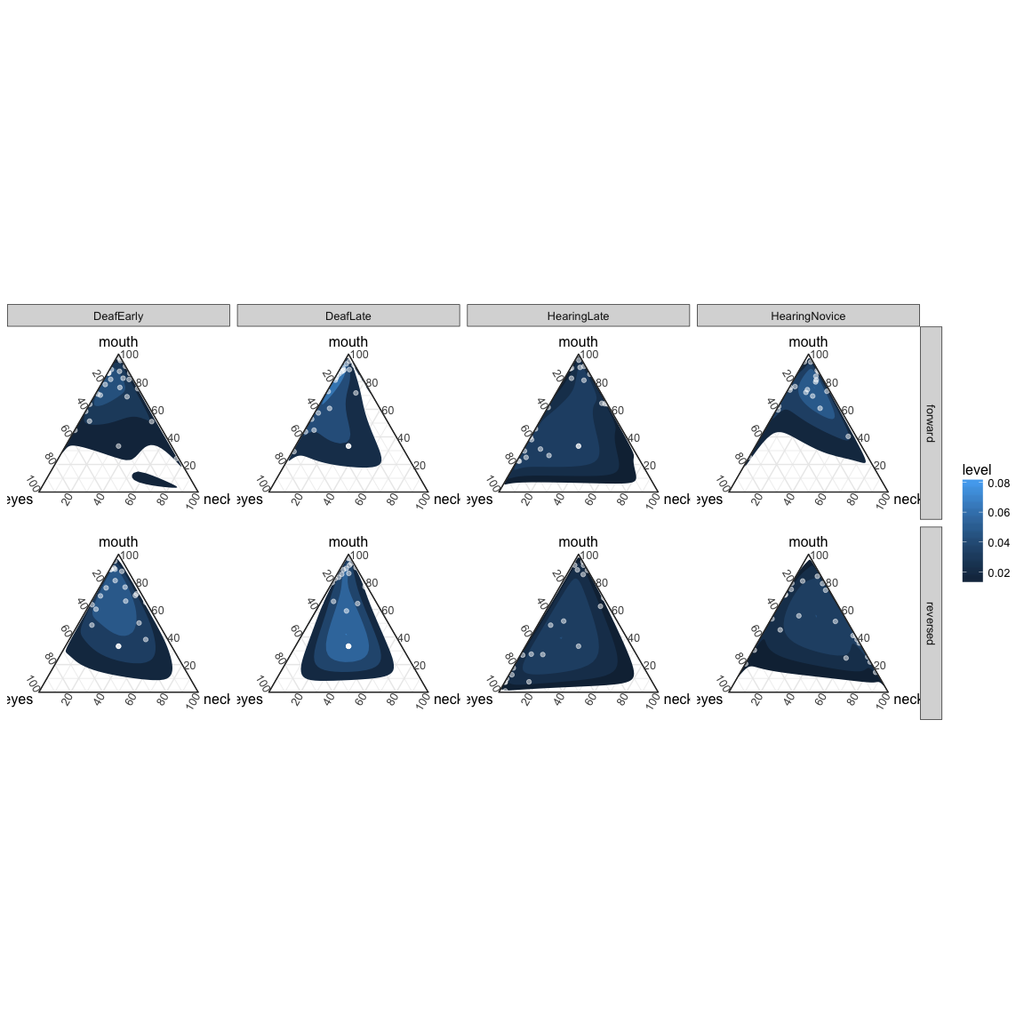

```r
library(ggtern)
fulldata %>%
  ggtern(aes(x = eyes, y = mouth, z = neck)) + facet_grid(direction ~ maingroup) + stat_density_tern(geom='polygon', aes(fill=..level..), bins=4) + geom_point(color = "white", alpha = 0.5) + theme_bw()
```

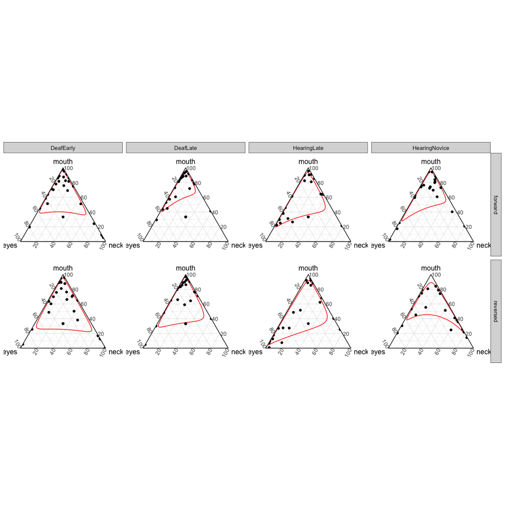

```r
fulldata %>%
  ggtern(aes(x = eyes, y = mouth, z = neck)) + facet_grid(direction ~ maingroup) + geom_confidence_tern(breaks = c(.5), color = "red") + geom_point() + theme_bw()
```

# Rain’s Notes

About Adults:

-I think I want to write it up as an ANCOVA, with direction included. And LSD comparisons instead of Tukey. (I will do my own corrections) -You often have one liners summarizing results, in all tabs, those are nice, keep them coming. -(If you have reasons to present anything other than the ANCOVA, put that in your results tab)

I think if we do it this way then we get a really important story to tell: That the *critical* AoA cutoff is below 4 vs above 4 years of age (two groups 0-4 vs 4-13). This suggest early ASL is important.

# Viewing Space Correlations

Okay now let’s work with the raw viewing space that we created in 05viewingspace. For each participant the first 30 samples was removed.

- box width
- upper limit
- lower limit
- left side
- right side
- height
- box center position
- area

correlated with

- gist
- lexical recall
- sign years
- aoasl

Here’s sample of the raw viewing data structure. I’m also going to fix participant names because the raw viewing data has the old participant names.

```r
viewing <- read_csv('../Adult Data/rawdata/adultviewingspaceraw.csv', progress=FALSE)
# Fix participant names
partnames <- read_csv("partnames.csv") %>%
  distinct() %>%
  mutate(participant = as.character(participant),
         new_participant = as.character(new_participant))
viewing <- left_join(viewing, partnames, by = "participant") %>%
  select(-participant) %>%
  rename(participant = new_participant) %>%
  filter(!is.na(participant)) %>%
  select(participant, group:maingroup)
# Show table
head(viewing, 10)
```

| participant | group | language | media | x | y | gazeindex | story | direction | maingroup |
| --- | --- | --- | --- | --- | --- | --- | --- | --- | --- |
| Adam | Deaf | Early | bears_forward | 703 | 392 | 30 | bears | forward | DeafEarly |
| Adam | Deaf | Early | bears_forward | 699 | 388 | 31 | bears | forward | DeafEarly |
| Adam | Deaf | Early | bears_forward | 697 | 384 | 32 | bears | forward | DeafEarly |
| Adam | Deaf | Early | bears_forward | 697 | 384 | 33 | bears | forward | DeafEarly |
| Adam | Deaf | Early | bears_forward | 694 | 382 | 34 | bears | forward | DeafEarly |
| Adam | Deaf | Early | bears_forward | 692 | 381 | 35 | bears | forward | DeafEarly |
| Adam | Deaf | Early | bears_forward | 694 | 383 | 36 | bears | forward | DeafEarly |
| Adam | Deaf | Early | bears_forward | 697 | 385 | 37 | bears | forward | DeafEarly |
| Adam | Deaf | Early | bears_forward | 693 | 383 | 38 | bears | forward | DeafEarly |
| Adam | Deaf | Early | bears_forward | 690 | 380 | 39 | bears | forward | DeafEarly |

Now I’m going to compute the following metrics with the following definitions!

```r
# compute viewing metrics
viewing_metrics <- viewing %>%
  group_by(participant, direction, media) %>%
  summarise(
    upper = quantile(y,na.rm=TRUE)[[2]],
    lower = quantile(y,na.rm=TRUE)[[4]],
    left = quantile(x,na.rm=TRUE)[[2]],
    right = quantile(x,na.rm=TRUE)[[4]],
    width = IQR(x,na.rm=TRUE),
    height = IQR(y,na.rm=TRUE),
    x_center = median(x,na.rm=TRUE),
    y_center = median(y,na.rm=TRUE),
    area = width*height
    )
# average across two stories for each direction
viewing_metrics <- viewing_metrics %>%
  group_by(participant, direction) %>%
  summarise_if(is.numeric, funs(mean(., na.rm = TRUE)))
head(viewing_metrics,10)
```

| participant | direction | upper | lower | left | right | width | height | x_center | y_center | area |
| --- | --- | --- | --- | --- | --- | --- | --- | --- | --- | --- |
| Adam | forward | 368.5 | 413.5 | 674.000 | 698.0 | 24.000 | 45.0 | 687.5 | 388.5 | 1132.00 |
| Adam | reversed | 358.5 | 398.5 | 683.000 | 707.0 | 24.000 | 40.0 | 695.5 | 379.0 | 890.00 |
| Alicia | forward | 382.0 | 421.5 | 683.500 | 713.5 | 30.000 | 39.5 | 701.5 | 405.0 | 1216.50 |
| Alicia | reversed | 380.0 | 417.5 | 659.625 | 705.0 | 45.375 | 37.5 | 684.5 | 398.0 | 1706.25 |
| Allison | forward | 310.0 | 366.5 | 723.750 | 794.0 | 70.250 | 56.5 | 764.5 | 336.0 | 4684.00 |
| Allison | reversed | 288.5 | 334.5 | 749.000 | 802.5 | 53.500 | 46.0 | 765.0 | 307.0 | 2442.50 |
| Alyssa | forward | 444.5 | 474.5 | 698.000 | 741.5 | 43.500 | 30.0 | 718.5 | 457.5 | 1344.00 |
| Alyssa | reversed | 435.0 | 465.5 | 713.875 | 753.5 | 39.625 | 30.5 | 735.0 | 447.5 | 1221.50 |
| Aman | forward | 365.0 | 388.5 | 703.750 | 734.0 | 30.250 | 23.5 | 719.0 | 377.5 | 715.25 |
| Aman | reversed | 343.5 | 364.0 | 704.000 | 721.5 | 17.500 | 20.5 | 712.5 | 352.5 | 368.50 |

Now I’ll join the behavioral data with the viewing space metrics. Below is an example of the forward table for viewing space and behavioral data

```r
# Get behavioral measures
eyeperf_fwrv <- fulldata %>%
  filter(eye_exclude == FALSE) %>%
  select(participant, maingroup, hearing, direction, aoasl, signyrs, selfrate, acc, gist, eyes, mouth, neck, facechest) %>%
  group_by(maingroup, participant, direction) %>%
  mutate(gist = mean(gist, na.rm = TRUE),
         lex = mean(acc, na.rm = TRUE),
         eyes = mean(eyes, na.rm = TRUE),
         mouth = mean(mouth, na.rm = TRUE),
         neck = mean(neck, na.rm = TRUE),
         facechest = mean(facechest, na.rm = TRUE)) %>%
  ungroup() %>%
  select(maingroup, participant, hearing, direction, aoasl, signyrs, selfrate, gist, lex) %>%
  distinct()
viewing_metrics_behav <-
  left_join(viewing_metrics, eyeperf_fwrv, by = c("participant","direction")) %>%
  filter(!is.na(maingroup)) %>%
  select(participant, direction, hearing, maingroup:lex, upper:area) %>%
  gather(metric, value, gist:area) %>%
  unite(metricvalue, c(metric, direction), sep = "_", remove = FALSE) %>%
  select(-metric) %>%
  spread(metricvalue, value) %>%
  ungroup() %>%
  select(-participant, -maingroup)
viewing_fw <- viewing_metrics_behav %>%
  filter(direction == "forward") %>%
  select(hearing,
         aoasl,
         signyrs,
         selfrate,
         gist_forward,
         lex_forward,
         upper_forward,
         lower_forward,
         left_forward,
         right_forward,
         width_forward,
         height_forward,
         x_center_forward,
         y_center_forward,
         area_forward)
viewing_fw_deaf <- viewing_fw %>%
  filter(hearing == "Deaf") %>%
  select(-hearing)
viewing_fw_hearing <- viewing_fw %>%
  filter(hearing == "Hearing") %>%
  select(-hearing)
viewing_rv <- viewing_metrics_behav %>%
  filter(direction == "reversed") %>%
  select(hearing,
         aoasl,
         signyrs,
         selfrate,
         gist_reversed,
         lex_reversed,
         upper_reversed,
         lower_reversed,
         left_reversed,
         right_reversed,
         width_reversed,
         height_reversed,
         x_center_reversed,
         y_center_reversed,
         area_reversed)
viewing_rv_deaf <- viewing_rv %>%
  filter(hearing == "Deaf") %>%
  select(-hearing)
viewing_rv_hearing <- viewing_rv %>%
  filter(hearing == "Hearing") %>%
  select(-hearing)
viewing_fw <- select(viewing_fw, -hearing)
viewing_rv <- select(viewing_rv, -hearing)
head(viewing_fw,10)
```

| aoasl | signyrs | selfrate | gist_forward | lex_forward | upper_forward | lower_forward | left_forward | right_forward | width_forward | height_forward | x_center_forward | y_center_forward | area_forward |
| --- | --- | --- | --- | --- | --- | --- | --- | --- | --- | --- | --- | --- | --- |
| 13 | 13.00 | 5 | 1 | 0.800 | 368.5 | 413.5 | 674.00 | 698.0 | 24.00 | 45.0 | 687.5 | 388.5 | 1132.00 |
| 14 | 23.00 | 5 | 1 | 0.975 | 382.0 | 421.5 | 683.50 | 713.5 | 30.00 | 39.5 | 701.5 | 405.0 | 1216.50 |
| 12 | 10.00 | 5 | 1 | 0.775 | 310.0 | 366.5 | 723.75 | 794.0 | 70.25 | 56.5 | 764.5 | 336.0 | 4684.00 |
| 0 | 22.00 | 5 | 1 | 0.800 | 444.5 | 474.5 | 698.00 | 741.5 | 43.50 | 30.0 | 718.5 | 457.5 | 1344.00 |
| 19 | 2.00 | 3 | 0 | 0.825 | 365.0 | 388.5 | 703.75 | 734.0 | 30.25 | 23.5 | 719.0 | 377.5 | 715.25 |
| 19 | 20.00 | 5 | 1 | 0.900 | 392.0 | 415.0 | 690.00 | 726.0 | 36.00 | 23.0 | 700.0 | 404.0 | 828.00 |
| 17 | 2.75 | 4 | 1 | 0.875 | 381.5 | 410.5 | 693.00 | 720.0 | 27.00 | 29.0 | 706.5 | 396.5 | 783.00 |
| 17 | 1.00 | 3 | 0 | 0.825 | 421.5 | 494.5 | 708.00 | 744.5 | 36.50 | 73.0 | 730.5 | 443.5 | 2648.00 |
| 13 | 21.00 | 5 | 1 | 0.775 | 389.5 | 419.0 | 691.50 | 721.5 | 30.00 | 29.5 | 709.5 | 403.5 | 887.50 |
| 22 | 6.00 | 5 | 1 | 0.950 | 411.5 | 447.0 | 745.50 | 790.0 | 44.50 | 35.5 | 769.5 | 430.0 | 1585.00 |

## Deaf Viewing Correlations, Forward

```r
print("Correlations - Pearson's r")
```

```
[1] "Correlations - Pearson's r"
```

```r
Hmisc::rcorr(as.matrix(viewing_fw_deaf))$r
```

```
                       aoasl    signyrs selfrate gist_forward  lex_forward upper_forward
aoasl             1.00000000 -0.5018827      NaN  0.082663718  0.117240289    0.22276900
signyrs          -0.50188271  1.0000000      NaN  0.183211261  0.385176624   -0.20595350
selfrate                 NaN        NaN        1          NaN          NaN           NaN
gist_forward      0.08266372  0.1832113      NaN  1.000000000 -0.051814432    0.04457362
lex_forward       0.11724029  0.3851766      NaN -0.051814432  1.000000000   -0.09693139
upper_forward     0.22276900 -0.2059535      NaN  0.044573617 -0.096931392    1.00000000
lower_forward     0.17740408 -0.1486075      NaN -0.009906705 -0.065050036    0.93384661
left_forward     -0.16560842  0.3251682      NaN  0.319111480 -0.038623876    0.11382223
right_forward    -0.06149620  0.2908277      NaN  0.161788931  0.027752331    0.14657307
width_forward     0.03814862  0.1200164      NaN -0.023894681  0.057139463    0.09332054
height_forward   -0.10832061  0.1429820      NaN -0.147926827  0.080896222   -0.10393404
x_center_forward -0.03683807  0.2590204      NaN  0.188047153  0.007652783    0.21590504
y_center_forward  0.21023138 -0.1656808      NaN  0.006174181 -0.070294840    0.97119234
area_forward      0.03468568  0.1029605      NaN -0.009832728  0.066630131    0.11923244
                 lower_forward left_forward right_forward width_forward height_forward
aoasl              0.177404081  -0.16560842   -0.06149620    0.03814862    -0.10832061
signyrs           -0.148607493   0.32516822    0.29082774    0.12001636     0.14298200
selfrate                   NaN          NaN           NaN           NaN            NaN
gist_forward      -0.009906705   0.31911148    0.16178893   -0.02389468    -0.14792683
lex_forward       -0.065050036  -0.03862388    0.02775233    0.05713946     0.08089622
upper_forward      0.933846611   0.11382223    0.14657307    0.09332054    -0.10393404
lower_forward      1.000000000   0.03679962    0.33757931    0.36274216     0.25867820
left_forward       0.036799624   1.00000000    0.49463212   -0.08905077    -0.20506900
right_forward      0.337579308   0.49463212    1.00000000    0.82160221     0.54286009
width_forward      0.362742157  -0.08905077    0.82160221    1.00000000     0.75664871
height_forward     0.258678199  -0.20506900    0.54286009    0.75664871     1.00000000
x_center_forward   0.362885211   0.60577642    0.97867576    0.72426205     0.42598456
y_center_forward   0.986980746   0.07188921    0.30117929    0.29801030     0.12161654
area_forward       0.402184750  -0.04656800    0.82760514    0.97901433     0.79634697
                 x_center_forward y_center_forward area_forward
aoasl                -0.036838067      0.210231379  0.034685675
signyrs               0.259020382     -0.165680761  0.102960533
selfrate                      NaN              NaN          NaN
gist_forward          0.188047153      0.006174181 -0.009832728
lex_forward           0.007652783     -0.070294840  0.066630131
upper_forward         0.215905043      0.971192341  0.119232443
lower_forward         0.362885211      0.986980746  0.402184750
left_forward          0.605776421      0.071889205 -0.046568004
right_forward         0.978675763      0.301179290  0.827605136
width_forward         0.724262047      0.298010301  0.979014327
height_forward        0.425984558      0.121616537  0.796346965
x_center_forward      1.000000000      0.345480098  0.754101461
y_center_forward      0.345480098      1.000000000  0.329823848
area_forward          0.754101461      0.329823848  1.000000000
```

```r
print("Correlations - P-values")
```

```
[1] "Correlations - P-values"
```

```r
Hmisc::rcorr(as.matrix(viewing_fw_deaf))$P
```

```
                       aoasl     signyrs selfrate gist_forward lex_forward upper_forward
aoasl                     NA 0.005536859      NaN   0.66988387  0.54472642  2.454197e-01
signyrs          0.005536859          NA      NaN   0.34144731  0.03907661  2.837870e-01
selfrate                 NaN         NaN       NA          NaN         NaN           NaN
gist_forward     0.669883870 0.341447313      NaN           NA  0.78951944  8.184091e-01
lex_forward      0.544726419 0.039076613      NaN   0.78951944          NA  6.169264e-01
upper_forward    0.245419728 0.283786999      NaN   0.81840913  0.61692641            NA
lower_forward    0.357228496 0.441679210      NaN   0.95932259  0.73743534  1.425526e-13
left_forward     0.390588606 0.085216837      NaN   0.09154227  0.84232477  5.565959e-01
right_forward    0.751319398 0.125876870      NaN   0.40176098  0.88636586  4.480250e-01
width_forward    0.844241358 0.535174502      NaN   0.90208021  0.76844399  6.301655e-01
height_forward   0.575946377 0.459344393      NaN   0.44379691  0.67656008  5.915861e-01
x_center_forward 0.849530891 0.174844814      NaN   0.32863243  0.96857212  2.606435e-01
y_center_forward 0.273682515 0.390378724      NaN   0.97464218  0.71709297  0.000000e+00
area_forward     0.858231980 0.595081840      NaN   0.95962610  0.73128783  5.378637e-01
                 lower_forward left_forward right_forward width_forward height_forward
aoasl             3.572285e-01 0.3905886058  7.513194e-01  8.442414e-01   5.759464e-01
signyrs           4.416792e-01 0.0852168366  1.258769e-01  5.351745e-01   4.593444e-01
selfrate                   NaN          NaN           NaN           NaN            NaN
gist_forward      9.593226e-01 0.0915422676  4.017610e-01  9.020802e-01   4.437969e-01
lex_forward       7.374353e-01 0.8423247730  8.863659e-01  7.684440e-01   6.765601e-01
upper_forward     1.425526e-13 0.5565958763  4.480250e-01  6.301655e-01   5.915861e-01
lower_forward               NA 0.8496861491  7.330173e-02  5.311918e-02   1.754355e-01
left_forward      8.496861e-01           NA  6.378305e-03  6.459661e-01   2.859055e-01
right_forward     7.330173e-02 0.0063783049            NA  4.682800e-08   2.343920e-03
width_forward     5.311918e-02 0.6459660901  4.682800e-08            NA   2.042503e-06
height_forward    1.754355e-01 0.2859055228  2.343920e-03  2.042503e-06             NA
x_center_forward  5.301852e-02 0.0004968573  0.000000e+00  8.922437e-06   2.121700e-02
y_center_forward  0.000000e+00 0.7109457062  1.123599e-01  1.163778e-01   5.297050e-01
area_forward      3.055416e-02 0.8104269085  3.063745e-08  0.000000e+00   2.383184e-07
                 x_center_forward y_center_forward area_forward
aoasl                8.495309e-01       0.27368252 8.582320e-01
signyrs              1.748448e-01       0.39037872 5.950818e-01
selfrate                      NaN              NaN          NaN
gist_forward         3.286324e-01       0.97464218 9.596261e-01
lex_forward          9.685721e-01       0.71709297 7.312878e-01
upper_forward        2.606435e-01       0.00000000 5.378637e-01
lower_forward        5.301852e-02       0.00000000 3.055416e-02
left_forward         4.968573e-04       0.71094571 8.104269e-01
right_forward        0.000000e+00       0.11235989 3.063745e-08
width_forward        8.922437e-06       0.11637775 0.000000e+00
height_forward       2.121700e-02       0.52970503 2.383184e-07
x_center_forward               NA       0.06641452 2.312126e-06
y_center_forward     6.641452e-02               NA 8.058557e-02
area_forward         2.312126e-06       0.08058557           NA
```

```r
corstarsl(viewing_fw_deaf)
```

|  | aoasl | signyrs | selfrate | gist_forward | lex_forward | upper_forward | lower_forward | left_forward | right_forward | width_forward | height_forward | x_center_forward | y_center_forward |
| --- | --- | --- | --- | --- | --- | --- | --- | --- | --- | --- | --- | --- | --- |
| aoasl |  |  |  |  |  |  |  |  |  |  |  |  |  |
| signyrs | -0.50** |  |  |  |  |  |  |  |  |  |  |  |  |
| selfrate | NaNNA | NaNNA |  |  |  |  |  |  |  |  |  |  |  |
| gist_forward | 0.08 | 0.18 | NaNNA |  |  |  |  |  |  |  |  |  |  |
| lex_forward | 0.12 | 0.39* | NaNNA | -0.05 |  |  |  |  |  |  |  |  |  |
| upper_forward | 0.22 | -0.21 | NaNNA | 0.04 | -0.10 |  |  |  |  |  |  |  |  |
| lower_forward | 0.18 | -0.15 | NaNNA | -0.01 | -0.07 | 0.93*** |  |  |  |  |  |  |  |
| left_forward | -0.17 | 0.33 | NaNNA | 0.32 | -0.04 | 0.11 | 0.04 |  |  |  |  |  |  |
| right_forward | -0.06 | 0.29 | NaNNA | 0.16 | 0.03 | 0.15 | 0.34 | 0.49** |  |  |  |  |  |
| width_forward | 0.04 | 0.12 | NaNNA | -0.02 | 0.06 | 0.09 | 0.36 | -0.09 | 0.82*** |  |  |  |  |

[output cut: 4 more lines]

## Deaf Viewing Correlations, Reversed

```r
print("Correlations - Pearson's r")
```

```
[1] "Correlations - Pearson's r"
```

```r
Hmisc::rcorr(as.matrix(viewing_rv_deaf))$r
```

```
                         aoasl     signyrs selfrate gist_reversed lex_reversed upper_reversed
aoasl              1.000000000 -0.50300054      NaN  -0.226608568 -0.167800596    0.101951202
signyrs           -0.503000541  1.00000000      NaN  -0.106652058 -0.025210812   -0.086768548
selfrate                   NaN         NaN        1           NaN          NaN            NaN
gist_reversed     -0.226608568 -0.10665206      NaN   1.000000000  0.303169035   -0.335941110
lex_reversed      -0.167800596 -0.02521081      NaN   0.303169035  1.000000000    0.008202664
upper_reversed     0.101951202 -0.08676855      NaN  -0.335941110  0.008202664    1.000000000
lower_reversed     0.113063926 -0.10887118      NaN  -0.368524049 -0.121148925    0.961254345
left_reversed     -0.201770397  0.32283237      NaN   0.037616571 -0.163974000   -0.106090037
right_reversed    -0.231537042  0.37951201      NaN  -0.046700900 -0.266614412   -0.293614256
width_reversed    -0.043917120  0.08763168      NaN  -0.164183307 -0.186162371   -0.352755582
height_reversed    0.007116611 -0.04774316      NaN  -0.010148541 -0.428809956   -0.417272208
x_center_reversed -0.198076727  0.32655812      NaN   0.002943648 -0.208773455   -0.189508307
y_center_reversed  0.105498214 -0.08154445      NaN  -0.371637459 -0.049562859    0.993730373
area_reversed     -0.047446603  0.05434785      NaN  -0.145123840 -0.368637739   -0.377499095
                  lower_reversed left_reversed right_reversed width_reversed height_reversed
aoasl                  0.1130639   -0.20177040    -0.23153704    -0.04391712     0.007116611
signyrs               -0.1088712    0.32283237     0.37951201     0.08763168    -0.047743159
selfrate                     NaN           NaN            NaN            NaN             NaN
gist_reversed         -0.3685240    0.03761657    -0.04670090    -0.16418331    -0.010148541
lex_reversed          -0.1211489   -0.16397400    -0.26661441    -0.18616237    -0.428809956
upper_reversed         0.9612543   -0.10609004    -0.29361426    -0.35275558    -0.417272208
lower_reversed         1.0000000   -0.19918550    -0.33227808    -0.24227207    -0.150587284
left_reversed         -0.1991855    1.00000000     0.86912864    -0.31632865    -0.276191762
right_reversed        -0.3322781    0.86912864     1.00000000     0.19425864    -0.042450731
width_reversed        -0.2422721   -0.31632865     0.19425864     1.00000000     0.466368814
height_reversed       -0.1505873   -0.27619176    -0.04245073     0.46636881     1.000000000
x_center_reversed     -0.2613117    0.97342941     0.95038194    -0.10777983    -0.181845074
y_center_reversed      0.9812746   -0.13741531    -0.30074865    -0.30431004    -0.328786893
area_reversed         -0.1558549   -0.37452036     0.05324661     0.84494541     0.839997806
                  x_center_reversed y_center_reversed area_reversed
aoasl                  -0.198076727        0.10549821   -0.04744660
signyrs                 0.326558116       -0.08154445    0.05434785
selfrate                        NaN               NaN           NaN
gist_reversed           0.002943648       -0.37163746   -0.14512384
lex_reversed           -0.208773455       -0.04956286   -0.36863774
upper_reversed         -0.189508307        0.99373037   -0.37749909
lower_reversed         -0.261311696        0.98127455   -0.15585490
left_reversed           0.973429412       -0.13741531   -0.37452036
right_reversed          0.950381943       -0.30074865    0.05324661
width_reversed         -0.107779835       -0.30431004    0.84494541
height_reversed        -0.181845074       -0.32878689    0.83999781
x_center_reversed       1.000000000       -0.21177835   -0.20833784
y_center_reversed      -0.211778355        1.00000000   -0.29641837
area_reversed          -0.208337840       -0.29641837    1.00000000
```

```r
print("Correlations - P-values")
```

```
[1] "Correlations - P-values"
```

```r
Hmisc::rcorr(as.matrix(viewing_rv_deaf))$P
```

```
                        aoasl     signyrs selfrate gist_reversed lex_reversed upper_reversed
aoasl                      NA 0.006366985      NaN    0.24621484   0.39337611   6.056954e-01
signyrs           0.006366985          NA      NaN    0.58908365   0.89867060   6.606379e-01
selfrate                  NaN         NaN       NA           NaN          NaN            NaN
gist_reversed     0.246214837 0.589083651      NaN            NA   0.11682334   8.050045e-02
lex_reversed      0.393376109 0.898670598      NaN    0.11682334           NA   9.669562e-01
upper_reversed    0.605695402 0.660637889      NaN    0.08050045   0.96695621             NA
lower_reversed    0.566750822 0.581311183      NaN    0.05364705   0.53914843   4.440892e-16
left_reversed     0.303183924 0.093818322      NaN    0.84927772   0.40440769   5.910593e-01
right_reversed    0.235814234 0.046386373      NaN    0.81344835   0.17023651   1.293989e-01
width_reversed    0.824392286 0.657464313      NaN    0.40379982   0.34287816   6.559217e-02
height_reversed   0.971329380 0.809359572      NaN    0.95912323   0.02279456   2.715960e-02
x_center_reversed 0.312306765 0.089874977      NaN    0.98813896   0.28635013   3.341168e-01
y_center_reversed 0.593142720 0.679967024      NaN    0.05150479   0.80223269   0.000000e+00
area_reversed     0.810522467 0.783567332      NaN    0.46122802   0.05356761   4.765470e-02
                  lower_reversed left_reversed right_reversed width_reversed height_reversed
aoasl               5.667508e-01  3.031839e-01   2.358142e-01   8.243923e-01    9.713294e-01
signyrs             5.813112e-01  9.381832e-02   4.638637e-02   6.574643e-01    8.093596e-01
selfrate                     NaN           NaN            NaN            NaN             NaN
gist_reversed       5.364705e-02  8.492777e-01   8.134483e-01   4.037998e-01    9.591232e-01
lex_reversed        5.391484e-01  4.044077e-01   1.702365e-01   3.428782e-01    2.279456e-02
upper_reversed      4.440892e-16  5.910593e-01   1.293989e-01   6.559217e-02    2.715960e-02
lower_reversed                NA  3.095506e-01   8.406690e-02   2.141845e-01    4.443424e-01
left_reversed       3.095506e-01            NA   1.979651e-09   1.010127e-01    1.548274e-01
right_reversed      8.406690e-02  1.979651e-09             NA   3.219137e-01    8.301702e-01
width_reversed      2.141845e-01  1.010127e-01   3.219137e-01             NA    1.236432e-02
height_reversed     4.443424e-01  1.548274e-01   8.301702e-01   1.236432e-02              NA
x_center_reversed   1.792184e-01  0.000000e+00   1.065814e-14   5.851280e-01    3.543850e-01
y_center_reversed   0.000000e+00  4.856146e-01   1.199199e-01   1.153842e-01    8.757679e-02
area_reversed       4.283817e-01  4.958172e-02   7.878531e-01   1.554224e-08    2.269863e-08
                  x_center_reversed y_center_reversed area_reversed
aoasl                  3.123068e-01        0.59314272  8.105225e-01
signyrs                8.987498e-02        0.67996702  7.835673e-01
selfrate                        NaN               NaN           NaN
gist_reversed          9.881390e-01        0.05150479  4.612280e-01
lex_reversed           2.863501e-01        0.80223269  5.356761e-02
upper_reversed         3.341168e-01        0.00000000  4.765470e-02
lower_reversed         1.792184e-01        0.00000000  4.283817e-01
left_reversed          0.000000e+00        0.48561456  4.958172e-02
right_reversed         1.065814e-14        0.11991989  7.878531e-01
width_reversed         5.851280e-01        0.11538424  1.554224e-08
height_reversed        3.543850e-01        0.08757679  2.269863e-08
x_center_reversed                NA        0.27931294  2.873796e-01
y_center_reversed      2.793129e-01                NA  1.256101e-01
area_reversed          2.873796e-01        0.12561011            NA
```

```r
corstarsl(viewing_rv_deaf)
```

|  | aoasl | signyrs | selfrate | gist_reversed | lex_reversed | upper_reversed | lower_reversed | left_reversed | right_reversed | width_reversed | height_reversed | x_center_reversed | y_center_reversed |
| --- | --- | --- | --- | --- | --- | --- | --- | --- | --- | --- | --- | --- | --- |
| aoasl |  |  |  |  |  |  |  |  |  |  |  |  |  |
| signyrs | -0.50** |  |  |  |  |  |  |  |  |  |  |  |  |
| selfrate | NaNNA | NaNNA |  |  |  |  |  |  |  |  |  |  |  |
| gist_reversed | -0.23 | -0.11 | NaNNA |  |  |  |  |  |  |  |  |  |  |
| lex_reversed | -0.17 | -0.03 | NaNNA | 0.30 |  |  |  |  |  |  |  |  |  |
| upper_reversed | 0.10 | -0.09 | NaNNA | -0.34 | 0.01 |  |  |  |  |  |  |  |  |
| lower_reversed | 0.11 | -0.11 | NaNNA | -0.37 | -0.12 | 0.96*** |  |  |  |  |  |  |  |
| left_reversed | -0.20 | 0.32 | NaNNA | 0.04 | -0.16 | -0.11 | -0.20 |  |  |  |  |  |  |
| right_reversed | -0.23 | 0.38* | NaNNA | -0.05 | -0.27 | -0.29 | -0.33 | 0.87*** |  |  |  |  |  |
| width_reversed | -0.04 | 0.09 | NaNNA | -0.16 | -0.19 | -0.35 | -0.24 | -0.32 | 0.19 |  |  |  |  |

[output cut: 4 more lines]

## Hearing Viewing Correlations, Forward

```r
print("Correlations - Pearson's r")
```

```
[1] "Correlations - Pearson's r"
```

```r
Hmisc::rcorr(as.matrix(viewing_fw_hearing))$r
```

```
                       aoasl     signyrs    selfrate gist_forward lex_forward upper_forward
aoasl             1.00000000 -0.07887014  0.01385561  -0.15525565  0.08908095    0.34941310
signyrs          -0.07887014  1.00000000  0.73847851   0.57814668  0.26130640   -0.13453355
selfrate          0.01385561  0.73847851  1.00000000   0.70963997  0.47076831   -0.13376451
gist_forward     -0.15525565  0.57814668  0.70963997   1.00000000  0.52977525   -0.23917461
lex_forward       0.08908095  0.26130640  0.47076831   0.52977525  1.00000000    0.05096588
upper_forward     0.34941310 -0.13453355 -0.13376451  -0.23917461  0.05096588    1.00000000
lower_forward     0.20590345 -0.22613997 -0.18677658  -0.28737646 -0.04066124    0.81072841
left_forward     -0.05141619  0.08821355  0.36718414   0.28496008  0.51274026   -0.03738438
right_forward    -0.21900963  0.11569295  0.41681940   0.33033867  0.52155630   -0.21593012
width_forward    -0.36826535  0.05341980  0.07835181   0.07606009 -0.02513886   -0.39384943
height_forward   -0.18298261 -0.17758474 -0.11227107  -0.12206492 -0.14608791   -0.14968228
x_center_forward -0.11209472  0.04108265  0.38386799   0.27761869  0.48736076   -0.08373722
y_center_forward  0.30487906 -0.19751061 -0.16246899  -0.25737919  0.02756594    0.97334262
area_forward     -0.34011139  0.06345770  0.05021929   0.03946279 -0.06444704   -0.33132094
                 lower_forward left_forward right_forward width_forward height_forward
aoasl               0.20590345  -0.05141619   -0.21900963   -0.36826535    -0.18298261
signyrs            -0.22613997   0.08821355    0.11569295    0.05341980    -0.17758474
selfrate           -0.18677658   0.36718414    0.41681940    0.07835181    -0.11227107
gist_forward       -0.28737646   0.28496008    0.33033867    0.07606009    -0.12206492
lex_forward        -0.04066124   0.51274026    0.52155630   -0.02513886    -0.14608791
upper_forward       0.81072841  -0.03738438   -0.21593012   -0.39384943    -0.14968228
lower_forward       1.00000000  -0.35104995   -0.33353656    0.06958863     0.45747549
left_forward       -0.35104995   1.00000000    0.90348212   -0.30194036    -0.53611208
right_forward      -0.33353656   0.90348212    1.00000000    0.13582274    -0.23533283
width_forward       0.06958863  -0.30194036    0.13582274    1.00000000     0.71576402
height_forward      0.45747549  -0.53611208   -0.23533283    0.71576402     1.00000000
x_center_forward   -0.29967060   0.97660262    0.95313558   -0.13742263    -0.37892901
y_center_forward    0.91343916  -0.15817767   -0.26314104   -0.21964976     0.06427939
area_forward        0.22571172  -0.48057627   -0.08236247    0.92762615     0.88446699
                 x_center_forward y_center_forward area_forward
aoasl                 -0.11209472       0.30487906  -0.34011139
signyrs                0.04108265      -0.19751061   0.06345770
selfrate               0.38386799      -0.16246899   0.05021929
gist_forward           0.27761869      -0.25737919   0.03946279
lex_forward            0.48736076       0.02756594  -0.06444704
upper_forward         -0.08373722       0.97334262  -0.33132094
lower_forward         -0.29967060       0.91343916   0.22571172
left_forward           0.97660262      -0.15817767  -0.48057627
right_forward          0.95313558      -0.26314104  -0.08236247
width_forward         -0.13742263      -0.21964976   0.92762615
height_forward        -0.37892901       0.06427939   0.88446699
x_center_forward       1.00000000      -0.16702029  -0.32508184
y_center_forward      -0.16702029       1.00000000  -0.13487348
area_forward          -0.32508184      -0.13487348   1.00000000
```

```r
print("Correlations - P-values")
```

```
[1] "Correlations - P-values"
```

```r
Hmisc::rcorr(as.matrix(viewing_fw_hearing))$P
```

```
                     aoasl      signyrs     selfrate gist_forward lex_forward upper_forward
aoasl                   NA 0.7205586083 0.9499685271 0.4793399006 0.686067097  1.022036e-01
signyrs          0.7205586           NA 0.0000573213 0.0038575060 0.228450650  5.405296e-01
selfrate         0.9499685 0.0000573213           NA 0.0001492417 0.023376769  5.428679e-01
gist_forward     0.4793399 0.0038575060 0.0001492417           NA 0.009323943  2.717140e-01
lex_forward      0.6860671 0.2284506503 0.0233767693 0.0093239427          NA  8.173593e-01
upper_forward    0.1022036 0.5405296237 0.5428679449 0.2717139922 0.817359252            NA
lower_forward    0.3459041 0.2994714694 0.3934694052 0.1836491479 0.853852321  2.718069e-06
left_forward     0.8157723 0.6889747833 0.0847895319 0.1875265304 0.012356772  8.655217e-01
right_forward    0.3153702 0.5991154130 0.0478577002 0.1236849613 0.010699696  3.223925e-01
width_forward    0.0838069 0.8087198039 0.7223242762 0.7301473181 0.909351946  6.296018e-02
height_forward   0.4033205 0.4175691700 0.6100345931 0.5790049656 0.505970588  4.954445e-01
x_center_forward 0.6105996 0.8523536985 0.0705591352 0.1996487227 0.018334617  7.040473e-01
y_center_forward 0.1572005 0.3663408883 0.4588967502 0.2357738122 0.900640350  6.661338e-15
area_forward     0.1123056 0.7736141099 0.8199918731 0.8581168782 0.770176021  1.225050e-01
                 lower_forward left_forward right_forward width_forward height_forward
aoasl             3.459041e-01 8.157723e-01  3.153702e-01  8.380690e-02   4.033205e-01
signyrs           2.994715e-01 6.889748e-01  5.991154e-01  8.087198e-01   4.175692e-01
selfrate          3.934694e-01 8.478953e-02  4.785770e-02  7.223243e-01   6.100346e-01
gist_forward      1.836491e-01 1.875265e-01  1.236850e-01  7.301473e-01   5.790050e-01
lex_forward       8.538523e-01 1.235677e-02  1.069970e-02  9.093519e-01   5.059706e-01
upper_forward     2.718069e-06 8.655217e-01  3.223925e-01  6.296018e-02   4.954445e-01
lower_forward               NA 1.004976e-01  1.198734e-01  7.523769e-01   2.817292e-02
left_forward      1.004976e-01           NA  3.541828e-09  1.614428e-01   8.365930e-03
right_forward     1.198734e-01 3.541828e-09            NA  5.366202e-01   2.797194e-01
width_forward     7.523769e-01 1.614428e-01  5.366202e-01            NA   1.229699e-04
height_forward    2.817292e-02 8.365930e-03  2.797194e-01  1.229699e-04             NA
x_center_forward  1.647737e-01 1.776357e-15  2.244871e-12  5.317870e-01   7.456754e-02
y_center_forward  1.180958e-09 4.710037e-01  2.250816e-01  3.139223e-01   7.707583e-01
area_forward      3.004121e-01 2.027749e-02  7.086984e-01  1.921421e-10   2.146623e-08
                 x_center_forward y_center_forward area_forward
aoasl                6.105996e-01     1.572005e-01 1.123056e-01
signyrs              8.523537e-01     3.663409e-01 7.736141e-01
selfrate             7.055914e-02     4.588968e-01 8.199919e-01
gist_forward         1.996487e-01     2.357738e-01 8.581169e-01
lex_forward          1.833462e-02     9.006403e-01 7.701760e-01
upper_forward        7.040473e-01     6.661338e-15 1.225050e-01
lower_forward        1.647737e-01     1.180958e-09 3.004121e-01
left_forward         1.776357e-15     4.710037e-01 2.027749e-02
right_forward        2.244871e-12     2.250816e-01 7.086984e-01
width_forward        5.317870e-01     3.139223e-01 1.921421e-10
height_forward       7.456754e-02     7.707583e-01 2.146623e-08
x_center_forward               NA     4.462352e-01 1.301398e-01
y_center_forward     4.462352e-01               NA 5.394975e-01
area_forward         1.301398e-01     5.394975e-01           NA
```

```r
corstarsl(viewing_fw_hearing)
```

|  | aoasl | signyrs | selfrate | gist_forward | lex_forward | upper_forward | lower_forward | left_forward | right_forward | width_forward | height_forward | x_center_forward | y_center_forward |
| --- | --- | --- | --- | --- | --- | --- | --- | --- | --- | --- | --- | --- | --- |
| aoasl |  |  |  |  |  |  |  |  |  |  |  |  |  |
| signyrs | -0.08 |  |  |  |  |  |  |  |  |  |  |  |  |
| selfrate | 0.01 | 0.74*** |  |  |  |  |  |  |  |  |  |  |  |
| gist_forward | -0.16 | 0.58** | 0.71*** |  |  |  |  |  |  |  |  |  |  |
| lex_forward | 0.09 | 0.26 | 0.47* | 0.53** |  |  |  |  |  |  |  |  |  |
| upper_forward | 0.35 | -0.13 | -0.13 | -0.24 | 0.05 |  |  |  |  |  |  |  |  |
| lower_forward | 0.21 | -0.23 | -0.19 | -0.29 | -0.04 | 0.81*** |  |  |  |  |  |  |  |
| left_forward | -0.05 | 0.09 | 0.37 | 0.28 | 0.51* | -0.04 | -0.35 |  |  |  |  |  |  |
| right_forward | -0.22 | 0.12 | 0.42* | 0.33 | 0.52* | -0.22 | -0.33 | 0.90*** |  |  |  |  |  |
| width_forward | -0.37 | 0.05 | 0.08 | 0.08 | -0.03 | -0.39 | 0.07 | -0.30 | 0.14 |  |  |  |  |

[output cut: 4 more lines]

## Hearing Viewing Correlations, Reversed

```r
print("Correlations - Pearson's r")
```

```
[1] "Correlations - Pearson's r"
```

```r
Hmisc::rcorr(as.matrix(viewing_rv_hearing))$r
```

```
                        aoasl     signyrs    selfrate gist_reversed lex_reversed upper_reversed
aoasl              1.00000000 -0.07887014  0.01385561   0.078157516   0.06994866     0.29120518
signyrs           -0.07887014  1.00000000  0.73847851   0.288457469   0.22209268    -0.22765477
selfrate           0.01385561  0.73847851  1.00000000   0.521440792   0.36876982    -0.18131365
gist_reversed      0.07815752  0.28845747  0.52144079   1.000000000   0.61989299     0.29483622
lex_reversed       0.06994866  0.22209268  0.36876982   0.619892993   1.00000000     0.22990466
upper_reversed     0.29120518 -0.22765477 -0.18131365   0.294836217   0.22990466     1.00000000
lower_reversed     0.27919511 -0.35447890 -0.20364781   0.174618778   0.08420977     0.79754835
left_reversed     -0.14427562  0.07819807  0.35847303   0.161581467   0.11546114    -0.09117055
right_reversed    -0.21672772  0.05733023  0.33877006   0.005462218   0.06471615    -0.25686115
width_reversed    -0.18005639 -0.05186101 -0.04896778  -0.387987042  -0.12611167    -0.41177214
height_reversed   -0.01361460 -0.20464317 -0.03864136  -0.184570722  -0.22603496    -0.30154539
x_center_reversed -0.15748245  0.08238514  0.36619379   0.088240227   0.10339721    -0.17253477
y_center_reversed  0.29856528 -0.27503476 -0.18721635   0.295955810   0.22641186     0.98072096
area_reversed     -0.05431629 -0.04452477  0.01864461  -0.350326607  -0.27433854    -0.40965102
                  lower_reversed left_reversed right_reversed width_reversed height_reversed
aoasl                 0.27919511   -0.14427562   -0.216727716    -0.18005639     -0.01361460
signyrs              -0.35447890    0.07819807    0.057330234    -0.05186101     -0.20464317
selfrate             -0.20364781    0.35847303    0.338770060    -0.04896778     -0.03864136
gist_reversed         0.17461878    0.16158147    0.005462218    -0.38798704     -0.18457072
lex_reversed          0.08420977    0.11546114    0.064716150    -0.12611167     -0.22603496
upper_reversed        0.79754835   -0.09117055   -0.256861147    -0.41177214     -0.30154539
lower_reversed        1.00000000   -0.24249436   -0.224835180     0.04388789      0.33467758
left_reversed        -0.24249436    1.00000000    0.919043897    -0.20119735     -0.24084955
right_reversed       -0.22483518    0.91904390    1.000000000     0.20118581      0.04588299
width_reversed        0.04388789   -0.20119735    0.201185807     1.00000000      0.71258642
height_reversed       0.33467758   -0.24084955    0.045882991     0.71258642      1.00000000
x_center_reversed    -0.23547460    0.98036143    0.966367121    -0.03478441     -0.10265730
y_center_reversed     0.88877414   -0.11486547   -0.237773596    -0.30544942     -0.12724651
area_reversed         0.18353484   -0.28033984    0.067378502     0.86414799      0.92998674
                  x_center_reversed y_center_reversed area_reversed
aoasl                   -0.15748245         0.2985653   -0.05431629
signyrs                  0.08238514        -0.2750348   -0.04452477
selfrate                 0.36619379        -0.1872164    0.01864461
gist_reversed            0.08824023         0.2959558   -0.35032661
lex_reversed             0.10339721         0.2264119   -0.27433854
upper_reversed          -0.17253477         0.9807210   -0.40965102
lower_reversed          -0.23547460         0.8887741    0.18353484
left_reversed            0.98036143        -0.1148655   -0.28033984
right_reversed           0.96636712        -0.2377736    0.06737850
width_reversed          -0.03478441        -0.3054494    0.86414799
height_reversed         -0.10265730        -0.1272465    0.92998674
x_center_reversed        1.00000000        -0.1714985   -0.11948840
y_center_reversed       -0.17149848         1.0000000   -0.26223203
area_reversed           -0.11948840        -0.2622320    1.00000000
```

```r
print("Correlations - P-values")
```

```
[1] "Correlations - P-values"
```

```r
Hmisc::rcorr(as.matrix(viewing_rv_hearing))$P
```

```
                      aoasl      signyrs     selfrate gist_reversed lex_reversed upper_reversed
aoasl                    NA 0.7205586083 0.9499685271   0.722986491  0.751135019   1.776188e-01
signyrs           0.7205586           NA 0.0000573213   0.181932485  0.308433961   2.961589e-01
selfrate          0.9499685 0.0000573213           NA   0.010720159  0.083351365   4.076969e-01
gist_reversed     0.7229865 0.1819324846 0.0107201595            NA  0.001604979   1.720272e-01
lex_reversed      0.7511350 0.3084339611 0.0833513648   0.001604979           NA   2.912809e-01
upper_reversed    0.1776188 0.2961588839 0.4076969259   0.172027240  0.291280889             NA
lower_reversed    0.1970021 0.0969920639 0.3513292733   0.425513766  0.702451010   5.178149e-06
left_reversed     0.5113189 0.7228482691 0.0930238744   0.461387355  0.599852518   6.790800e-01
right_reversed    0.3205647 0.7949973825 0.1138204336   0.980266257  0.769241540   2.367512e-01
width_reversed    0.4110110 0.8142053576 0.8244091489   0.067343150  0.566387826   5.090588e-02
height_reversed   0.9508378 0.3489291557 0.8610420739   0.399180414  0.299701961   1.620190e-01
x_center_reversed 0.4729803 0.7086216120 0.0856971286   0.688885303  0.638723603   4.311445e-01
y_center_reversed 0.1664130 0.2040386253 0.3923363331   0.170328040  0.298875228   2.220446e-16
area_reversed     0.8055689 0.8401318272 0.9327090230   0.101248876  0.205232495   5.223092e-02
                  lower_reversed left_reversed right_reversed width_reversed height_reversed
aoasl               1.970021e-01  5.113189e-01   3.205647e-01   4.110110e-01    9.508378e-01
signyrs             9.699206e-02  7.228483e-01   7.949974e-01   8.142054e-01    3.489292e-01
selfrate            3.513293e-01  9.302387e-02   1.138204e-01   8.244091e-01    8.610421e-01
gist_reversed       4.255138e-01  4.613874e-01   9.802663e-01   6.734315e-02    3.991804e-01
lex_reversed        7.024510e-01  5.998525e-01   7.692415e-01   5.663878e-01    2.997020e-01
upper_reversed      5.178149e-06  6.790800e-01   2.367512e-01   5.090588e-02    1.620190e-01
lower_reversed                NA  2.649147e-01   3.023431e-01   8.423906e-01    1.185342e-01
left_reversed       2.649147e-01            NA   5.996887e-10   3.572792e-01    2.682698e-01
right_reversed      3.023431e-01  5.996887e-10             NA   3.573074e-01    8.353189e-01
width_reversed      8.423906e-01  3.572792e-01   3.573074e-01             NA    1.360488e-04
height_reversed     1.185342e-01  2.682698e-01   8.353189e-01   1.360488e-04              NA
x_center_reversed   2.794214e-01  2.220446e-16   7.305268e-14   8.748001e-01    6.411393e-01
y_center_reversed   1.469011e-08  6.017484e-01   2.746164e-01   1.563863e-01    5.628717e-01
area_reversed       4.018782e-01  1.950953e-01   7.600135e-01   1.071790e-07    1.370859e-10
                  x_center_reversed y_center_reversed area_reversed
aoasl                  4.729803e-01      1.664130e-01  8.055689e-01
signyrs                7.086216e-01      2.040386e-01  8.401318e-01
selfrate               8.569713e-02      3.923363e-01  9.327090e-01
gist_reversed          6.888853e-01      1.703280e-01  1.012489e-01
lex_reversed           6.387236e-01      2.988752e-01  2.052325e-01
upper_reversed         4.311445e-01      2.220446e-16  5.223092e-02
lower_reversed         2.794214e-01      1.469011e-08  4.018782e-01
left_reversed          2.220446e-16      6.017484e-01  1.950953e-01
right_reversed         7.305268e-14      2.746164e-01  7.600135e-01
width_reversed         8.748001e-01      1.563863e-01  1.071790e-07
height_reversed        6.411393e-01      5.628717e-01  1.370859e-10
x_center_reversed                NA      4.339592e-01  5.871013e-01
y_center_reversed      4.339592e-01                NA  2.267467e-01
area_reversed          5.871013e-01      2.267467e-01            NA
```

```r
corstarsl(viewing_rv_hearing)
```

|  | aoasl | signyrs | selfrate | gist_reversed | lex_reversed | upper_reversed | lower_reversed | left_reversed | right_reversed | width_reversed | height_reversed | x_center_reversed | y_center_reversed |
| --- | --- | --- | --- | --- | --- | --- | --- | --- | --- | --- | --- | --- | --- |
| aoasl |  |  |  |  |  |  |  |  |  |  |  |  |  |
| signyrs | -0.08 |  |  |  |  |  |  |  |  |  |  |  |  |
| selfrate | 0.01 | 0.74*** |  |  |  |  |  |  |  |  |  |  |  |
| gist_reversed | 0.08 | 0.29 | 0.52* |  |  |  |  |  |  |  |  |  |  |
| lex_reversed | 0.07 | 0.22 | 0.37 | 0.62** |  |  |  |  |  |  |  |  |  |
| upper_reversed | 0.29 | -0.23 | -0.18 | 0.29 | 0.23 |  |  |  |  |  |  |  |  |
| lower_reversed | 0.28 | -0.35 | -0.20 | 0.17 | 0.08 | 0.80*** |  |  |  |  |  |  |  |
| left_reversed | -0.14 | 0.08 | 0.36 | 0.16 | 0.12 | -0.09 | -0.24 |  |  |  |  |  |  |
| right_reversed | -0.22 | 0.06 | 0.34 | 0.01 | 0.06 | -0.26 | -0.22 | 0.92*** |  |  |  |  |  |
| width_reversed | -0.18 | -0.05 | -0.05 | -0.39 | -0.13 | -0.41 | 0.04 | -0.20 | 0.20 |  |  |  |  |

[output cut: 4 more lines]

## All Viewing Correlations, Forward

```r
print("Correlations - Pearson's r")
```

```
[1] "Correlations - Pearson's r"
```

```r
Hmisc::rcorr(as.matrix(viewing_fw))$r
```

```
                        aoasl     signyrs     selfrate gist_forward  lex_forward upper_forward
aoasl             1.000000000 -0.78522450 -0.506162780 -0.323090309 -0.142631690   0.001356982
signyrs          -0.785224499  1.00000000  0.709593416  0.495618291  0.363347176   0.060403594
selfrate         -0.506162780  0.70959342  1.000000000  0.734904339  0.461124386   0.075103941
gist_forward     -0.323090309  0.49561829  0.734904339  1.000000000  0.487500111  -0.030892283
lex_forward      -0.142631690  0.36334718  0.461124386  0.487500111  1.000000000   0.033564922
upper_forward     0.001356982  0.06040359  0.075103941 -0.030892283  0.033564922   1.000000000
lower_forward    -0.006478702  0.03249385  0.021259710 -0.088990001 -0.006277048   0.895914754
left_forward     -0.092727087  0.13149298  0.288534412  0.282620913  0.397213416   0.029398539
right_forward    -0.055398102  0.10558031  0.239055036  0.249726848  0.346656182  -0.019205190
width_forward     0.041759354 -0.01759425 -0.027238292 -0.002695181 -0.010451179  -0.069875701
height_forward   -0.017349603 -0.05616254 -0.112550975 -0.132791275 -0.085513496  -0.130894700
x_center_forward -0.070069701  0.12029249  0.266321218  0.244784902  0.345540652   0.073676443
y_center_forward -0.019405542  0.07602873  0.072900352 -0.038638736  0.036020310   0.972782277
area_forward     -0.006446590  0.03916390  0.007284405  0.008445134 -0.000269198  -0.001654218
                 lower_forward left_forward right_forward width_forward height_forward
aoasl             -0.006478702  -0.09272709   -0.05539810   0.041759354    -0.01734960
signyrs            0.032493854   0.13149298    0.10558031  -0.017594255    -0.05616254
selfrate           0.021259710   0.28853441    0.23905504  -0.027238292    -0.11255097
gist_forward      -0.088990001   0.28262091    0.24972685  -0.002695181    -0.13279127
lex_forward       -0.006277048   0.39721342    0.34665618  -0.010451179    -0.08551350
upper_forward      0.895914754   0.02939854   -0.01920519  -0.069875701    -0.13089470
lower_forward      1.000000000  -0.16475325    0.01644207   0.251135368     0.32313353
left_forward      -0.164753246   1.00000000    0.76998750  -0.184553709    -0.43031510
right_forward      0.016442071   0.76998750    1.00000000   0.484994616     0.07760803
width_forward      0.251135368  -0.18455371    0.48499462   1.000000000     0.70932760
height_forward     0.323133527  -0.43031510    0.07760803   0.709327601     1.00000000
x_center_forward   0.034056606   0.87139157    0.95923973   0.283226906    -0.08095059
y_center_forward   0.962259137  -0.04127392    0.04347490   0.123535393     0.07515167
area_forward       0.343583009  -0.22389339    0.42376270   0.959601109     0.77031146
                 x_center_forward y_center_forward area_forward
aoasl                 -0.07006970      -0.01940554 -0.006446590
signyrs                0.12029249       0.07602873  0.039163904
selfrate               0.26632122       0.07290035  0.007284405
gist_forward           0.24478490      -0.03863874  0.008445134
lex_forward            0.34554065       0.03602031 -0.000269198
upper_forward          0.07367644       0.97278228 -0.001654218
lower_forward          0.03405661       0.96225914  0.343583009
left_forward           0.87139157      -0.04127392 -0.223893386
right_forward          0.95923973       0.04347490  0.423762703
width_forward          0.28322691       0.12353539  0.959601109
height_forward        -0.08095059       0.07515167  0.770311458
x_center_forward       1.00000000       0.10167993  0.257811768
y_center_forward       0.10167993       1.00000000  0.203034404
area_forward           0.25781177       0.20303440  1.000000000
```

```r
print("Correlations - P-values")
```

```
[1] "Correlations - P-values"
```

```r
Hmisc::rcorr(as.matrix(viewing_fw))$P
```

```
                        aoasl      signyrs     selfrate gist_forward  lex_forward upper_forward
aoasl                      NA 5.523138e-12 1.290502e-04 1.947866e-02 0.3131194308     0.9923823
signyrs          5.523138e-12           NA 3.880305e-09 1.870210e-04 0.0081064913     0.6705620
selfrate         1.290502e-04 3.880305e-09           NA 5.548224e-10 0.0005807582     0.5966908
gist_forward     1.947866e-02 1.870210e-04 5.548224e-10           NA 0.0002468462     0.8278935
lex_forward      3.131194e-01 8.106491e-03 5.807582e-04 2.468462e-04           NA     0.8132598
upper_forward    9.923823e-01 6.705620e-01 5.966908e-01 8.278935e-01 0.8132597516            NA
lower_forward    9.636423e-01 8.191170e-01 8.810833e-01 5.304212e-01 0.9647732695     0.0000000
left_forward     5.132272e-01 3.527841e-01 3.804048e-02 4.235051e-02 0.0035487005     0.8360980
right_forward    6.964847e-01 4.563149e-01 8.786113e-02 7.419046e-02 0.0118154757     0.8925040
width_forward    7.688045e-01 9.014742e-01 8.479938e-01 9.848708e-01 0.9413808296     0.6225537
height_forward   9.028376e-01 6.925025e-01 4.269533e-01 3.480087e-01 0.5466668491     0.3549982
x_center_forward 6.215856e-01 3.956335e-01 5.633837e-02 8.029520e-02 0.0121084854     0.6037052
y_center_forward 8.913893e-01 5.921659e-01 6.075337e-01 7.856557e-01 0.7998708837     0.0000000
area_forward     9.638224e-01 7.828127e-01 9.591245e-01 9.526181e-01 0.9984887883     0.9907138
                 lower_forward left_forward right_forward width_forward height_forward
aoasl               0.96364234 5.132272e-01  6.964847e-01  7.688045e-01   9.028376e-01
signyrs             0.81911699 3.527841e-01  4.563149e-01  9.014742e-01   6.925025e-01
selfrate            0.88108331 3.804048e-02  8.786113e-02  8.479938e-01   4.269533e-01
gist_forward        0.53042122 4.235051e-02  7.419046e-02  9.848708e-01   3.480087e-01
lex_forward         0.96477327 3.548700e-03  1.181548e-02  9.413808e-01   5.466668e-01
upper_forward       0.00000000 8.360980e-01  8.925040e-01  6.225537e-01   3.549982e-01
lower_forward               NA 2.431422e-01  9.078974e-01  7.251963e-02   1.946145e-02
left_forward        0.24314223           NA  2.519274e-11  1.902743e-01   1.451862e-03
right_forward       0.90789743 2.519274e-11            NA  2.685495e-04   5.844742e-01
width_forward       0.07251963 1.902743e-01  2.685495e-04            NA   3.956054e-09
height_forward      0.01946145 1.451862e-03  5.844742e-01  3.956054e-09             NA
x_center_forward    0.81057430 0.000000e+00  0.000000e+00  4.189120e-02   5.683451e-01
y_center_forward    0.00000000 7.714191e-01  7.595850e-01  3.829247e-01   5.964569e-01
area_forward        0.01263779 1.105780e-01  1.745315e-03  0.000000e+00   2.442246e-11
                 x_center_forward y_center_forward area_forward
aoasl                  0.62158561        0.8913893 9.638224e-01
signyrs                0.39563346        0.5921659 7.828127e-01
selfrate               0.05633837        0.6075337 9.591245e-01
gist_forward           0.08029520        0.7856557 9.526181e-01
lex_forward            0.01210849        0.7998709 9.984888e-01
upper_forward          0.60370519        0.0000000 9.907138e-01
lower_forward          0.81057430        0.0000000 1.263779e-02
left_forward           0.00000000        0.7714191 1.105780e-01
right_forward          0.00000000        0.7595850 1.745315e-03
width_forward          0.04189120        0.3829247 0.000000e+00
height_forward         0.56834513        0.5964569 2.442246e-11
x_center_forward               NA        0.4732121 6.500208e-02
y_center_forward       0.47321205               NA 1.488528e-01
area_forward           0.06500208        0.1488528           NA
```

```r
corstarsl(viewing_fw)
```

|  | aoasl | signyrs | selfrate | gist_forward | lex_forward | upper_forward | lower_forward | left_forward | right_forward | width_forward | height_forward | x_center_forward | y_center_forward |
| --- | --- | --- | --- | --- | --- | --- | --- | --- | --- | --- | --- | --- | --- |
| aoasl |  |  |  |  |  |  |  |  |  |  |  |  |  |
| signyrs | -0.79*** |  |  |  |  |  |  |  |  |  |  |  |  |
| selfrate | -0.51*** | 0.71*** |  |  |  |  |  |  |  |  |  |  |  |
| gist_forward | -0.32* | 0.50*** | 0.73*** |  |  |  |  |  |  |  |  |  |  |
| lex_forward | -0.14 | 0.36** | 0.46*** | 0.49*** |  |  |  |  |  |  |  |  |  |
| upper_forward | 0.00 | 0.06 | 0.08 | -0.03 | 0.03 |  |  |  |  |  |  |  |  |
| lower_forward | -0.01 | 0.03 | 0.02 | -0.09 | -0.01 | 0.90*** |  |  |  |  |  |  |  |
| left_forward | -0.09 | 0.13 | 0.29* | 0.28* | 0.40** | 0.03 | -0.16 |  |  |  |  |  |  |
| right_forward | -0.06 | 0.11 | 0.24 | 0.25 | 0.35* | -0.02 | 0.02 | 0.77*** |  |  |  |  |  |
| width_forward | 0.04 | -0.02 | -0.03 | 0.00 | -0.01 | -0.07 | 0.25 | -0.18 | 0.48*** |  |  |  |  |

[output cut: 4 more lines]

## All Viewing Correlations, Reversed

```r
print("Correlations - Pearson's r")
```

```
[1] "Correlations - Pearson's r"
```

```r
Hmisc::rcorr(as.matrix(viewing_rv))$r
```

```
                         aoasl     signyrs     selfrate gist_reversed lex_reversed
aoasl              1.000000000 -0.78501877 -0.504229778   -0.32326383  -0.25779732
signyrs           -0.785018765  1.00000000  0.707270523    0.23410877   0.24984565
selfrate          -0.504229778  0.70727052  1.000000000    0.37615052   0.35782852
gist_reversed     -0.323263833  0.23410877  0.376150518    1.00000000   0.44831458
lex_reversed      -0.257797316  0.24984565  0.357828518    0.44831458   1.00000000
upper_reversed    -0.029121456  0.05225378  0.014765698   -0.08009174   0.14140325
lower_reversed     0.080000070 -0.09483062 -0.091817862   -0.16535317  -0.01946623
left_reversed     -0.114980591  0.12695911  0.245822704    0.09016509   0.01160483
right_reversed    -0.069880383  0.06205640  0.177639216   -0.03496294  -0.07538368
width_reversed     0.103094745 -0.14764744 -0.157195654   -0.28178791  -0.19495084
height_reversed    0.220610570 -0.29881825 -0.213945336   -0.16083704  -0.33627427
x_center_reversed -0.097804099  0.10798841  0.241739152    0.03978310  -0.01230045
y_center_reversed -0.004638618  0.02209785 -0.006599445   -0.11125724   0.10234025
area_reversed      0.201892375 -0.24148085 -0.179041636   -0.27645513  -0.33555475
                  upper_reversed lower_reversed left_reversed right_reversed width_reversed
aoasl                -0.02912146     0.08000007   -0.11498059    -0.06988038     0.10309475
signyrs               0.05225378    -0.09483062    0.12695911     0.06205640    -0.14764744
selfrate              0.01476570    -0.09181786    0.24582270     0.17763922    -0.15719565
gist_reversed        -0.08009174    -0.16535317    0.09016509    -0.03496294    -0.28178791
lex_reversed          0.14140325    -0.01946623    0.01160483    -0.07538368    -0.19495084
upper_reversed        1.00000000     0.88218429   -0.08753213    -0.26386130    -0.39311413
lower_reversed        0.88218429     1.00000000   -0.21623909    -0.25873458    -0.09112289
left_reversed        -0.08753213    -0.21623909    1.00000000     0.90108289    -0.23997959
right_reversed       -0.26386130    -0.25873458    0.90108289     1.00000000     0.20473332
width_reversed       -0.39311413    -0.09112289   -0.23997959     0.20473332     1.00000000
height_reversed      -0.34682568     0.13571095   -0.24653567     0.03980714     0.64558840
x_center_reversed    -0.16607710    -0.23499404    0.97773315     0.95974998    -0.05838507
y_center_reversed     0.98829936     0.93523651   -0.11419866    -0.25582980    -0.31494344
area_reversed        -0.38088456     0.05863852   -0.29277378     0.07789063     0.83521109
                  height_reversed x_center_reversed y_center_reversed area_reversed
aoasl                  0.22061057       -0.09780410      -0.004638618    0.20189237
signyrs               -0.29881825        0.10798841       0.022097855   -0.24148085
selfrate              -0.21394534        0.24173915      -0.006599445   -0.17904164
gist_reversed         -0.16083704        0.03978310      -0.111257241   -0.27645513
lex_reversed          -0.33627427       -0.01230045       0.102340250   -0.33555475
upper_reversed        -0.34682568       -0.16607710       0.988299358   -0.38088456
lower_reversed         0.13571095       -0.23499404       0.935236505    0.05863852
left_reversed         -0.24653567        0.97773315      -0.114198661   -0.29277378
right_reversed         0.03980714        0.95974998      -0.255829796    0.07789063
width_reversed         0.64558840       -0.05838507      -0.314943438    0.83521109
height_reversed        1.00000000       -0.11863818      -0.216540955    0.91814743
x_center_reversed     -0.11863818        1.00000000      -0.175098450   -0.13330268
y_center_reversed     -0.21654095       -0.17509845       1.000000000   -0.26857140
area_reversed          0.91814743       -0.13330268      -0.268571396    1.00000000
```

```r
print("Correlations - P-values")
```

```
[1] "Correlations - P-values"
```

```r
Hmisc::rcorr(as.matrix(viewing_rv))$P
```

```
                         aoasl      signyrs     selfrate gist_reversed lex_reversed
aoasl                       NA 9.197088e-12 1.615663e-04  0.0206764678 0.0677889947
signyrs           9.197088e-12           NA 6.557450e-09  0.0982310702 0.0770305455
selfrate          1.615663e-04 6.557450e-09           NA  0.0065211919 0.0099363454
gist_reversed     2.067647e-02 9.823107e-02 6.521192e-03            NA 0.0009694894
lex_reversed      6.778899e-02 7.703055e-02 9.936345e-03  0.0009694894           NA
upper_reversed    8.392476e-01 7.157353e-01 9.180903e-01  0.5763743641 0.3222859767
lower_reversed    5.768124e-01 5.080154e-01 5.216457e-01  0.2462172934 0.8921508964
left_reversed     4.217212e-01 3.746526e-01 8.207078e-02  0.5291998072 0.9355825975
right_reversed    6.260668e-01 6.653039e-01 2.123629e-01  0.8075640417 0.5990619544
width_reversed    4.715785e-01 3.011578e-01 2.706195e-01  0.0451475489 0.1704039043
height_reversed   1.197907e-01 3.317021e-02 1.316792e-01  0.2595352956 0.0158363529
x_center_reversed 4.947427e-01 4.506796e-01 8.744839e-02  0.7816461193 0.9317301547
y_center_reversed 9.742286e-01 8.776754e-01 9.633409e-01  0.4370078971 0.4748461015
area_reversed     1.553942e-01 8.779760e-02 2.087169e-01  0.0495534531 0.0160762000
                  upper_reversed lower_reversed left_reversed right_reversed width_reversed
aoasl                0.839247623     0.57681236    0.42172116     0.62606685   4.715785e-01
signyrs              0.715735280     0.50801540    0.37465263     0.66530394   3.011578e-01
selfrate             0.918090325     0.52164571    0.08207078     0.21236295   2.706195e-01
gist_reversed        0.576374364     0.24621729    0.52919981     0.80756404   4.514755e-02
lex_reversed         0.322285977     0.89215090    0.93558260     0.59906195   1.704039e-01
upper_reversed                NA     0.00000000    0.54134423     0.06135351   4.321717e-03
lower_reversed       0.000000000             NA    0.12749190     0.06676057   5.248155e-01
left_reversed        0.541344230     0.12749190            NA     0.00000000   8.984879e-02
right_reversed       0.061353509     0.06676057    0.00000000             NA   1.495402e-01
width_reversed       0.004321717     0.52481555    0.08984879     0.14954024             NA
height_reversed      0.012654284     0.34234309    0.08115912     0.78151742   3.135205e-07
x_center_reversed    0.244126400     0.09692972    0.00000000     0.00000000   6.840348e-01
y_center_reversed    0.000000000     0.00000000    0.42490602     0.06998894   2.438493e-02
area_reversed        0.005826220     0.68273549    0.03707699     0.58693238   2.531308e-14
                  height_reversed x_center_reversed y_center_reversed area_reversed
aoasl                1.197907e-01        0.49474269        0.97422861  1.553942e-01
signyrs              3.317021e-02        0.45067958        0.87767544  8.779760e-02
selfrate             1.316792e-01        0.08744839        0.96334091  2.087169e-01
gist_reversed        2.595353e-01        0.78164612        0.43700790  4.955345e-02
lex_reversed         1.583635e-02        0.93173015        0.47484610  1.607620e-02
upper_reversed       1.265428e-02        0.24412640        0.00000000  5.826220e-03
lower_reversed       3.423431e-01        0.09692972        0.00000000  6.827355e-01
left_reversed        8.115912e-02        0.00000000        0.42490602  3.707699e-02
right_reversed       7.815174e-01        0.00000000        0.06998894  5.869324e-01
width_reversed       3.135205e-07        0.68403479        0.02438493  2.531308e-14
height_reversed                NA        0.40700481        0.12694840  0.000000e+00
x_center_reversed    4.070048e-01                NA        0.21908160  3.510565e-01
y_center_reversed    1.269484e-01        0.21908160                NA  5.670101e-02
area_reversed        0.000000e+00        0.35105650        0.05670101            NA
```

```r
corstarsl(viewing_rv)
```

|  | aoasl | signyrs | selfrate | gist_reversed | lex_reversed | upper_reversed | lower_reversed | left_reversed | right_reversed | width_reversed | height_reversed | x_center_reversed | y_center_reversed |
| --- | --- | --- | --- | --- | --- | --- | --- | --- | --- | --- | --- | --- | --- |
| aoasl |  |  |  |  |  |  |  |  |  |  |  |  |  |
| signyrs | -0.79*** |  |  |  |  |  |  |  |  |  |  |  |  |
| selfrate | -0.50*** | 0.71*** |  |  |  |  |  |  |  |  |  |  |  |
| gist_reversed | -0.32* | 0.23 | 0.38** |  |  |  |  |  |  |  |  |  |  |
| lex_reversed | -0.26 | 0.25 | 0.36** | 0.45*** |  |  |  |  |  |  |  |  |  |
| upper_reversed | -0.03 | 0.05 | 0.01 | -0.08 | 0.14 |  |  |  |  |  |  |  |  |
| lower_reversed | 0.08 | -0.09 | -0.09 | -0.17 | -0.02 | 0.88*** |  |  |  |  |  |  |  |
| left_reversed | -0.11 | 0.13 | 0.25 | 0.09 | 0.01 | -0.09 | -0.22 |  |  |  |  |  |  |
| right_reversed | -0.07 | 0.06 | 0.18 | -0.03 | -0.08 | -0.26 | -0.26 | 0.90*** |  |  |  |  |  |
| width_reversed | 0.10 | -0.15 | -0.16 | -0.28* | -0.19 | -0.39** | -0.09 | -0.24 | 0.20 |  |  |  |  |

[output cut: 4 more lines]